# Spring River at Hardy, AR — hydrologic regime 1981–2026

Author

Spring River study (USGS 07069305 / NWS HDYA4)

Published

August 25, 2026

# 1 Abstract

Spring River at Hardy, AR (USGS 07069305) is a spring-fed Ozark river whose base flow is set by Mammoth Spring (07069190) and whose floods are set by basin rainfall. Over the systematic record (Hardy WY 2002–2026, Mammoth WY 1981–2026; 98.5% of Hardy daily discharge approved) the 7-day annual low flow at Hardy rose (Sen slope 0.023 log-cfs/yr (95% CI 0.00736 to 0.0361); MK z=3.05, p=0.002; n=24), but antecedent precipitation and ENSO explain it (OLS R² = 0.41, n = 24) and the non-climatic residual trend is indistinguishable from zero at Mammoth Spring, the 1981+ primary series (Sen slope -0.00126 log-cfs/yr (95% CI -0.00326 to 0.00122); MK z=-0.91, p=0.363; n=42). At Hardy the residual is positive (Sen slope 0.0203 log-cfs/yr (95% CI 0.00915 to 0.0291); MK z=3.99, p=0.000; n=24), and Phase 8 establishes this as a finding rather than a source artifact: log(Hardy min7 / Mammoth min7), which needs no precipitation model at all, rises +0.0124/yr (95 % CI 0.0028 to 0.022, p = 0.002, n = 24), and dropping the never-significant ENSO term makes the residual rise resolvable on 3 of 3 basin sources (§4.1). Base flow after the 6 major (≥16 ft) floods was higher, not lower, than in precipitation- and antecedent-matched non-flood years, but the two gauges differ once the procedure is placebo-tested (§4.3): at Mammoth +26.0% (bootstrap 95% CI 15.7 to 41) against a placebo mean of +0.6% — none of 200 placebo trials reaches it — while at Hardy +30.7% sits against a placebo mean of +9.7% that 11% of trials reach, and falls to +8.0% (CI spanning zero) when the post window starts 90 days after the event. Mammoth stands; roughly a third of Hardy’s figure is procedural and part of the rest is recession water (descriptive, not causal). The falling stage floor is a real channel change, not a rating artifact: stage at 1000 cfs fell (Sen slope -0.0187 ft/yr (95% CI -0.0214 to -0.0157); MK z=-5.46, p=0.000; n=19), and USGS field measurements — where both the discharge and the stage are measured at the visit, so neither is rating-derived — put stage at 400 cfs falling Sen slope -0.0149 ft/yr (95% CI -0.0219 to -0.0105); MK z=-4.19, p=0.000; n=20 over 33 visits (§4.2). Flood frequency shows no detectable change: Imboden annual peaks Sen slope 0.00112 log10-cfs/yr (95% CI -0.00123 to 0.00406); MK z=0.94, p=0.346; n=89; the pre-/post-2008 10-yr quantiles (63,943 vs 95,546 cfs) have overlapping 5–95% bootstrap intervals. LP3 return periods at Hardy (n = 24) put 10 ft at 1.4 yr and 16 ft at 4.5 yr (empirical 4). At the major-exposure tier the systematic-only fit is biased long because it excludes the known 1982 crest; adding it back as historical information (Bulletin 17B weighting) gives 20 ft 10–13 yr and 23 ft **20–29 yr**, which is how those two should be quoted (§5.1). Major-flood inter-arrivals show no detectable cadence (CV 1.01, bootstrap p = 0.47, n = 7) — but at this n a memoryless process routinely produces a CV anywhere in 0.42–1.5, and the test reaches 80 % power only against a near-metronomic cadence, so this is an absence of evidence rather than evidence of absence (§5.4). Precipitation over the recharge area is not becoming wetter and no intensification is detectable once a product discontinuity is allowed for. The annual total does not rise (+0.96 in/decade, 95% CI -1.2 to 3.1, n = 45) and the Sep–Feb recharge-season total is flat to negative (-0.806 in/decade, CI -2 to 0.6) — the study’s most robust precipitation result. The apparent rise in AORC’s storm-sharpness indices is a **step at the 2002 radar onset, not a trend**: with a step term, SDII’s slope is -0.002/decade (p = 0.86) while the step itself is significant (p = 0.00097), and within-era Sen slopes are flat to negative on every sharpness index. Over identical years AORC’s SDII rises +36% against +1% at the co-located gauge, while the two products agree on how much rain fell (+9% vs +11%). The first edition’s significant annual-total rise was a p-value threshold crossing, not a property of the 30 km buffer: the buffer−polygon difference has no detectable trend (+0.272 in/decade, CI spanning zero, r = 0.984) (§7.1). The 76-year West Plains 1948– gauge record (COOP to Mar 1998, then the airport ASOS raised by the measured catch ratio) does not corroborate the intensification over its own record or over AORC’s identical window, and what significance it does carry is knife-edge: only the count of days ≥ 1 in is BH-significant (+0.703/decade, CI 0.26 to 1.2), and it passes at the measured catch ratio 1.068 but not at 1.00 or 1.034 (§7.3). Monthly basin precipitation anomalies lead Mammoth Spring flow by 1 month (r = 0.45, 95% CI 0.41 to 0.52, n = 539 months); at daily resolution the response begins within 2 days and decays monotonically, so the monthly figure is the coarsest bin capturing a fast onset plus a long tail, not a transit time (§8). Flood timing is a broad late-winter mode with no drift detectable on the long record (Imboden annual peaks mean date 24 Feb, R = 0.49, n = 89; Watson–Williams across 10 decades p = 0.32), and recession constants show no trend (Hardy median k 14 days, Sen slope 0.0618 days/yr (95% CI -0.215 to 0.401); MK z=0.50, p=0.620; n=16; Mammoth Spring 188 days, Sen slope 0.216 days/yr (95% CI -1.03 to 1.7); MK z=0.41, p=0.681; n=80). No conclusion changed when provisional data were excluded.

# 2 Setting

- **River gauge.** USGS 07069305 Spring River at Hardy, AR (NWS HDYA4). Daily discharge WY 2002–present; 15-min stage from 2007-10-01; 24 annual peaks (WY 2002–2025). There is no USGS daily-stage product at Hardy; daily stage is the daily maximum of the instantaneous record.
- **Long flood record.** USGS 07069500 Spring River at Imboden, AR, downstream: daily discharge from 1936 and 89 annual peaks (WY 1937–2025 in the NWIS peak file).
- **Spring.** USGS 07069190 Mammoth Spring at Mammoth Spring, AR: the vent gauge, daily discharge from 1981-02-25 with no gaps > 7 days. It carries the 1981+ base-flow record; Hardy is the WY 2002+ series.
- **Recharge basin.** The MoDNR / Missouri Geological Survey “Mammoth Spring Recharge Area” polygon (revised layer 2022-09-14; 361 mi² stated, ~349 mi² equal-area), south-east of West Plains toward Alton and Thayer. Basin precipitation is the NOAA AORC v1.1 1 km hourly analysis averaged over the polygon (daily totals are the 24 h ending 12 UTC); the AORC bucket ends at `2025.zarr`, so the basin series runs 1981-01-02 to 2025-12-31. PRISM 4 km over the same polygon is the second opinion and runs to within a day of today (§7.1). The first edition’s 30 km West Plains buffer was ~3× the polygon’s area and offset north-west. Station series: USC00238880 West Plains COOP (1981+ in this build), KUNO West Plains ASOS (1998-04+), USC00230127 Alton COOP (1981+ pulled, but no data 1983–1994 or 2012–2016, so 24 years pass the coverage gate). A fourth station series, **West Plains 1948–**, runs the town COOP gauge back to 1948 and takes every day from 1998-04-01 from the KUNO ASOS instead, raised by the measured COOP/KUNO catch ratio so the record stays on the town gauge’s level; no day is borrowed between gauges, and the switch removes the COOP gauge’s 2011–2021 observer gaps, giving 76 index years (§7.3).
- **Flood categories (NWS HDYA4).** Action 8 ft, minor 10 ft, moderate 14 ft, major 16 ft. Record crest 29.0 ft on 1982-12-03 (flow not reported), before the systematic Hardy record.
- **Conventions.** Water year (Oct–Sep) for hydrologic statistics; calendar year for precipitation totals; recharge season Sep–Feb. No interpolation across gaps > 7 days. Every analysis is run on all data and on approved-only data; any conclusion that changes is flagged.

# 3 Data and QA

Full gap maps, cross-check residuals and the deferred QA items are in `docs/qa_report.md`.

Table 1: Series inventory and QA summary (from docs/qa_report.md, generated 2026-08-24). Gap boundaries are the first and last missing day.

| series | rows | span | approved | provisional_from | gaps_gt7d |
| --- | --- | --- | --- | --- | --- |
| Hardy DV discharge 07069305 | 9083 | 2001-10-01 → 2026-08-23 | 0.985 | 2026-04-09 | 0 |
| Imboden DV discharge 07069500 | 13915 | 1981-01-01 → 2026-08-23 | 0.988 | 2026-03-10 | 2 |
| Hardy daily-max IV stage 07069305 | 6858 | 2007-10-01 → 2026-08-24 | 0.98 | 2026-04-09 | 2 |
| Mammoth Spring DV discharge 07069190 | 16616 | 1981-02-25 → 2026-08-23 | 0.992 | 2026-04-09 | 0 |
| KUNO ASOS precip | 16672 | 1981-01-01 → 2026-08-24 | n/a (no flag) | n/a | 2 |
| USC00238880 COOP precip | 16672 | 1981-01-01 → 2026-08-24 | n/a (no flag) | n/a | 32 |

Table 2: Annual ledger, water years with complete Hardy records (data/processed/annual_ledger.parquet). Threshold-day counts use daily-max IV stage and are NA before WY 2008.

| WY | peak (cfs) | peak stage (ft) | days ≥ 8 ft | days ≥ 16 ft | min7 (cfs) | BFI | cal-yr precip (in) | Sep–Feb precip (in) |
| --- | --- | --- | --- | --- | --- | --- | --- | --- |
| 2002 | 1.93e+04 | 11.48 |  |  | 222.1 | 0.6963 | 62.49 | 22.96 |
| 2003 | 4630 | 6.36 |  |  | 342.9 | 0.7797 | 47.79 | 15.82 |
| 2004 | 4.41e+04 | 14.66 |  |  | 219.9 | 0.7395 | 46.48 | 23.48 |
| 2005 | 1.33e+04 | 9.71 |  |  | 191 | 0.7501 | 41.79 | 24.89 |
| 2006 | 4.45e+04 | 16.75 |  |  | 215 | 0.6821 | 58.64 | 20.44 |
| 2007 | 1.8e+04 | 11.11 |  |  | 270.1 | 0.7149 | 35.51 | 32.52 |
| 2008 | 8.07e+04 | 22.29 | 12 | 4 | 328.1 | 0.5951 | 62.27 | 20.51 |
| 2009 | 9900 | 8.55 | 2 | 0 | 352.6 | 0.7372 | 53.03 | 19.69 |
| 2010 | 4.88e+04 | 17.41 | 8 | 1 | 416.3 | 0.7206 | 35.47 | 33.1 |
| 2011 | 6.98e+04 | 20.73 | 8 | 2 | 332.4 | 0.6248 | 29.11 | 14.85 |
| 2012 | 9240 | 8.25 | 1 | 0 | 337 | 0.7714 | 24.8 | 24.48 |
| 2013 | 1.26e+04 | 9.4 | 3 | 0 | 293.3 | 0.7587 | 33.33 | 23.02 |
| 2014 | 2.09e+04 | 11.39 | 3 | 0 | 362.9 | 0.7318 | 38.29 | 20.52 |
| 2015 | 2.02e+04 | 11.21 | 10 | 0 | 446.9 | 0.7193 | 54.98 | 22.9 |
| 2016 | 3.99e+04 | 15.6 | 9 | 0 | 408.9 | 0.6914 | 37.76 | 25.8 |
| 2017 | 4.54e+04 | 16.65 | 5 | 1 | 419.4 | 0.6886 | 49.85 | 15.74 |
| 2018 | 9790 | 8.11 | 1 | 0 | 326.3 | 0.7592 | 51.87 | 14.07 |
| 2019 | 1.72e+04 | 10.37 | 3 | 0 | 335.9 | 0.7235 | 55.37 | 26.36 |
| 2020 | 1.5e+04 | 9.76 | 8 | 0 | 474.6 | 0.7309 | 57.04 | 22.22 |
| 2021 | 3.93e+04 | 15.45 | 4 | 0 | 391.4 | 0.7498 | 50.01 | 16.9 |
| 2022 | 1.9e+04 | 10.85 | 6 | 0 | 383.3 | 0.7409 | 51.1 | 19.41 |
| 2023 | 2.86e+04 | 13.19 | 6 | 0 | 374.1 | 0.7454 | 42.93 | 18.28 |
| 2024 | 4820 | 6.1 | 0 | 0 | 352.9 | 0.7661 | 57.59 | 15.9 |
| 2025 | 8.37e+04 | 22.82 | 15 | 2 | 400.6 | 0.6562 | 50.6 | 26.88 |

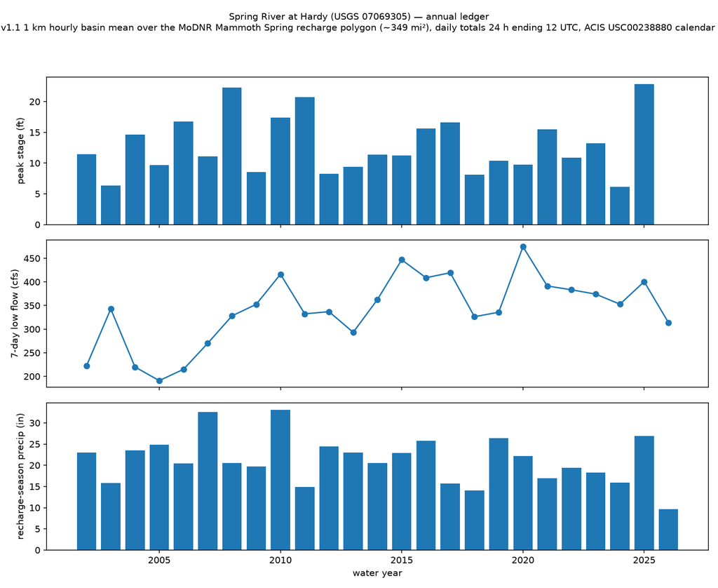

# 4 Base-flow regime

Thesis: at Mammoth Spring base flow tracks antecedent precipitation with no detectable structural decline; at Hardy it rose for a reason precipitation does not explain; and the drop in the stage floor is a real channel change, confirmed by measurements that do not depend on the rating.

## 4.1 Low-flow trend and attribution (Q1)

Predictors are strictly antecedent to each water year’s min7 window: basin precipitation over the 365 days ending the day before the window, the 365 days before that, and mean ONI over the 6 months ending the month before. Incomplete water years are excluded. Model: OLS log(min7) ~ p_trailing + p_trailing_prev + ONI (HC3 SEs); the residual is trend-tested (Mann-Kendall, Sen slope with Gilbert CI).

Table 3: Q1 low-flow trend and attribution. Raw min7 trends recomputed from reports/tables/phase4_attribution_*.parquet; residual trend and OLS terms from docs/phase4_baseflow.md.

| series | raw min7 trend (log-cfs/yr) | Pettitt | OLS R² (n) | p_trailing coef (per in) | ONI coef | residual trend (log-cfs/yr) |
| --- | --- | --- | --- | --- | --- | --- |
| Mammoth Spring 07069190 | Sen slope 0.000319 /yr (95% CI -0.00376 to 0.00357); MK z=0.13, p=0.897; n=42 | after WY 2008 (p=0.260) | 0.58 (42) | 0.0156 (0.0111 to 0.0201) | 0.011 (-0.023 to 0.046) | Sen slope -0.00126 /yr (95% CI -0.00326 to 0.00122); MK z=-0.91, p=0.363; n=42 |
| Hardy 07069305 | Sen slope 0.023 /yr (95% CI 0.00736 to 0.0361); MK z=3.05, p=0.002; n=24 | after WY 2013 (p=0.013) | 0.41 (24) | 0.0231 (0.0088 to 0.0375) | 0.048 (-0.080 to 0.176) | Sen slope 0.0203 /yr (95% CI 0.00915 to 0.0291); MK z=3.99, p=0.000; n=24 |

- Mammoth (1981+, the primary series): raw min7 is flat (Sen slope 0.000319 log-cfs/yr (95% CI -0.00376 to 0.00357); MK z=0.13, p=0.897; n=42); the residual after climate is Sen slope -0.00126 log-cfs/yr (95% CI -0.00326 to 0.00122); MK z=-0.91, p=0.363; n=42 — a point estimate of -1.3% per decade with a CI spanning zero.
- Hardy (WY 2002+): raw min7 rises (Sen slope 0.023 log-cfs/yr (95% CI 0.00736 to 0.0361); MK z=3.05, p=0.002; n=24; Pettitt step after WY 2013, p = 0.013), but trailing-365-day precipitation carries the signal (coefficient 0.0231 log-cfs per inch, 95% CI 0.0088 to 0.0375); it does not carry all of it: the residual still rises (Sen slope 0.0203 log-cfs/yr (95% CI 0.00915 to 0.0291); MK z=3.99, p=0.000; n=24). The second edition called this source-dependent and declined to conclude from it. That hedge is now retired — see the two checks below, neither of which uses a gridded precipitation product.
- **The Hardy rise, without any precipitation model.** Mammoth Spring is the best available climate control for Hardy: the same recharge climate, absorbing precipitation, ENSO, PET and any gridded-precipitation bias at once. If Hardy’s rise were climate it would vanish against Mammoth. It does not — log(Hardy min7 / Mammoth min7) rises Sen slope 0.0124 log-ratio/yr (95% CI 0.00278 to 0.0219); MK z=3.05, p=0.002; n=24, with a Pettitt change-point after WY 2014 (p = 0.029). Separately, dropping the never-significant ONI term — which at n ≈ 24 costs a degree of freedom for nothing — leaves Hardy’s residual rise with a CI excluding zero on 3 of 3 basin sources (AORC, PRISM-polygon and PRISM-buffer). The source-dependence was one weak regressor, not a fragile signal. **The rise is a finding.** Its cause is the channel change in §4.2 plus a reach gain the spring alone does not account for.
- **The Mammoth null, stated precisely.** Across three basin sources and two trailing-window lengths (365 and 730 d — a karst spring with a ~188-day recession constant may remember rain longer than the convention assumes), 1 of 6 specifications have a CI excluding zero, all on the negative side, and the PRISM fits are consistently marginally negative. The conclusion survives on the primary series, but “≈0 on all three sources” claims a unanimity the numbers do not support.
- Base-flow index (gap-segmented Eckhardt; Lyne-Hollick as check) has no trend: Mammoth Sen slope 2.3e-05 BFI/yr (95% CI -4.6e-05 to 0.00012); MK z=0.75, p=0.451; n=45; Hardy Sen slope 0.0013 BFI/yr (95% CI -0.0014 to 0.0038); MK z=1.10, p=0.272; n=25. **This is not evidence against a base-flow change.** BFI is a ratio, and at a spring-fed river it sits near 1, so it is nearly blind to a change in the absolute base-flow rate: base flow and total flow can rise together and leave it flat. It is reported as stated and must not be cited as corroboration.

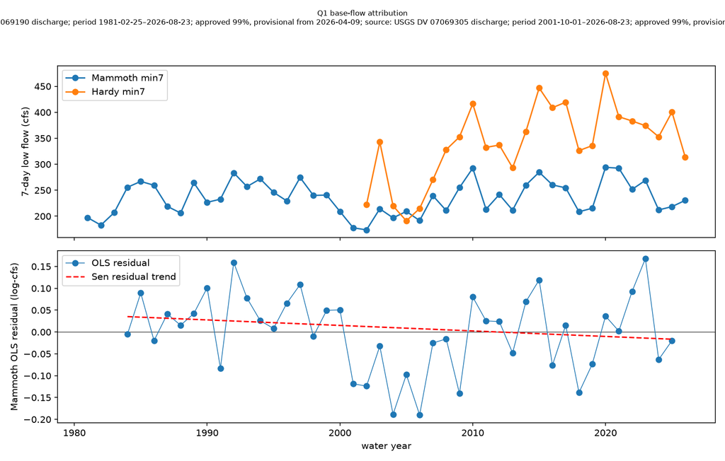

Figure 2: Q1 base-flow attribution: min7 at Mammoth and Hardy (top); Mammoth OLS residual with Sen trend (bottom). source: USGS DV 07069190 discharge; period 1981-02-25–2026-08-23; approved 99%, provisional from 2026-04-09; source: USGS DV 07069305 discharge; period 2001-10-01–2026-08-23; approved 99%, provisional from 2026-04-09.

Limitation: Hardy n = 24 water years; the ONI coefficient is not resolved at either gauge, which is why the precip-only fits above are the ones to read; AORC before 2002 is a gauge/reanalysis blend without radar (§7.2). Change-points: Hardy min7 steps after WY 2013 (p = 0.013), but Mammoth’s apparent WY 2008 step is **not significant** (p = 0.26) and must not be set beside it as though the two agreed. What would settle the cause of the Hardy gain is synoptic seepage runs (Mammoth → South Fork → Hardy at low flow), not more statistics on these series.

## 4.2 Rating drift (Q5)

Stage at a fixed discharge from 666,986 matched 15-min (stage, discharge) pairs: a local log-linear fit (stage = a + b·log10 Q over pairs within ±20 % of the target) per water year, evaluated at 400 and 1000 cfs.

Table 4: Stage at 400 and 1000 cfs by water year (reports/tables/phase4_rating_drift.parquet).

| WY | stage @400 cfs (ft) | stage @1000 cfs (ft) |
| --- | --- | --- |
| 2008.00 | 3.27 | 3.94 |
| 2009.00 | 3.21 | 3.88 |
| 2010.00 | 3.03 | 3.79 |
| 2011.00 | 3.05 | 3.73 |
| 2012.00 | 3.04 | 3.76 |
| 2013.00 | 3.11 | 3.75 |
| 2014.00 | 3.05 | 3.71 |
| 2015.00 | 3.03 | 3.71 |
| 2016.00 | 3.04 | 3.65 |
| 2017.00 | 2.99 | 3.67 |
| 2018.00 | 3.01 | 3.63 |
| 2019.00 | 3.01 | 3.62 |
| 2020.00 | 3.01 | 3.62 |
| 2021.00 | 3.01 | 3.57 |
| 2022.00 | 3.01 | 3.57 |
| 2023.00 | 2.95 | 3.55 |
| 2024.00 | 2.96 | 3.53 |
| 2025.00 | 2.97 | 3.52 |
| 2026.00 | 2.95 | 3.56 |

- Stage at 400 cfs: Sen slope -0.00791 ft/yr (95% CI -0.0132 to -0.00491); MK z=-4.41, p=0.000; n=19. Stage at 1000 cfs: Sen slope -0.0187 ft/yr (95% CI -0.0214 to -0.0157); MK z=-5.46, p=0.000; n=19 — about 0.19 ft per decade of channel-bed lowering or rating shift at moderate flow, unrelated to discharge.
- Shifts across individual ≥16 ft events (±365-day windows) range -0.18 to +0.02 ft; the drift is gradual rather than event-stepped.

Table 5: Stage-at-flow shift across ≥16 ft events, 365 days before vs after (docs/phase4_baseflow.md). The 2006-09-23 event predates the IV record.

| event_date | flow_cfs | stage_before_ft | stage_after_ft | shift_ft | n_before | n_after |
| --- | --- | --- | --- | --- | --- | --- |
| 2008-03-19 | 400 | 3.33 | 3.21 | -0.12 | 8678 | 12473 |
| 2008-03-19 | 1000 | 4.02 | 3.88 | -0.14 | 1845 | 4376 |
| 2009-10-30 | 400 | 3.21 | 3.03 | -0.18 | 9634 | 7263 |
| 2009-10-30 | 1000 | 3.88 | 3.79 | -0.08 | 6332 | 6189 |
| 2011-04-26 | 400 | 3.05 | 3.04 | -0.01 | 18468 | 5578 |
| 2011-04-26 | 1000 | 3.83 | 3.73 | -0.1 | 4003 | 9803 |
| 2017-04-30 | 400 | 2.99 | 3.01 | 0.02 | 3960 | 16859 |
| 2017-04-30 | 1000 | 3.65 | 3.66 | 0 | 7079 | 4930 |
| 2025-04-05 | 400 | 2.97 | 2.96 | -0.01 | 3853 | 16078 |
| 2025-04-05 | 1000 | 3.53 | 3.52 | -0.01 | 9474 | 1852 |

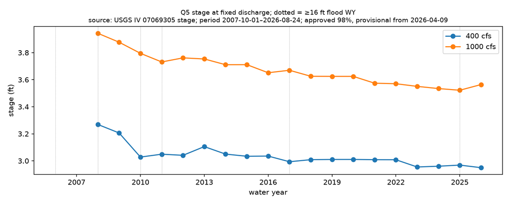

Figure 3: Q5 stage at fixed discharge by water year; dotted lines mark ≥16 ft flood water years. source: USGS IV 07069305 discharge+stage; period 2007-10-01–2026-08-24; approved 98%, provisional from 2026-04-09.

**The drift is a real channel change, not a rating artifact.** The objection to the two numbers above is that both come from IV pairs whose discharge is itself rating-derived, so a drifting rating would produce a drifting stage-at-flow with no channel change at all. USGS field measurements answer it: at each visit the discharge is measured by wading or ADCP and the stage is read directly, so neither side depends on the rating. Normalised to 400 cfs across the 330–520 cfs band, measured stage falls Sen slope -0.0149 ft/yr (95% CI -0.0219 to -0.0105); MK z=-4.19, p=0.000; n=20 over 33 visits — steeper than the IV-derived figure, four years longer, and it brackets the 2006-09-23 event the shift table has to omit. The channel really degraded; the rating followed it.

The agreement between measured and computed low flow is **not** independent evidence, because USGS shifts the rating to these very measurements; era means are 2001–2007 +1.3% (sd 5.1), 2008–2014 -1.1% (sd 4.0), 2015–2025 -0.3% (sd 3.3), 2026 +3.3% (sd 3.3), which is a few per cent either side of zero with scatter several times larger — not the “~1 % in every era” the second edition reported.

Limitation: the USGS rating-shift tables are still unobtained. The **datum history has now been reviewed** and rules out the obvious artifact: the gauge datum carries two revisions (340.91→342.49 ft before Dec 2022, then 342.49→342.73 ft), both post-2022 bookkeeping of the datum elevation, with no site move and nothing at WY2008.

### 4.2.1 Stage–discharge relationship

Across the 666,986 matched pairs, log10 stage and log10 discharge correlate at Pearson r = 0.969 (Spearman ρ = 0.963); the annual-peak log-log fit used in §9 is log10 Q = 1.954 + 2.215·log10 H (R² = 0.991, n = 24 peaks).

Table 6: Stage → discharge lookup at Hardy: median discharge of IV pairs within ±0.05 ft of each stage, whole record vs recent (pairs from 2023-10-01, WY 2024+); blank where fewer than 20 pairs (reports/tables/phase4_rating_table.parquet; IQR in the parquet).

| stage (ft) | whole-record median (cfs) | recent median (cfs) | n whole-record | n recent |
| --- | --- | --- | --- | --- |
| 3 | 396 | 427 | 110,130 | 23,363 |
| 3.5 | 834 | 968 | 35,941 | 4,783 |
| 4 | 1,370 | 1,620 | 23,156 | 2,933 |
| 5 | 2,780 | 2,980 | 4,828 | 378 |
| 6 | 4,550 | 4,610 | 1,184 | 99 |
| 8 | 9,480 | 9,560 | 185 | 34 |
| 10 | 15,700 | — | 72 | 2 |
| 12 | 23,300 | — | 34 | 8 |
| 14 | 31,000 | — | 39 | 2 |

Table 7: Flow percentiles of Hardy daily discharge mapped to stage: median stage of recent pairs within ±3 % of each flow (reports/tables/phase4_rating_percentiles.parquet).

| Hardy DV percentile | flow (cfs) | recent stage (ft) | n pairs ±3 % |
| --- | --- | --- | --- |
| 5 | 328 | 2.87 | 2,865 |
| 25 | 440 | 3 | 4,485 |
| 50 | 690 | 3.23 | 3,227 |
| 75 | 1,230 | 3.73 | 1,735 |
| 95 | 2,859 | 4.91 | 379 |

- The paddling range lives inside about 2.0 ft of stage: the 5th to 95th percentile of daily discharge (328–2,859 cfs) spans 2.87–4.91 ft on the recent rating, and the median day (690 cfs) reads 3.23 ft.
- The same stage carries more water now than the record-wide median at the low end: at 3.0–4.0 ft the recent median discharge is +8 to +18 % above the whole-record value, the lookup-table expression of the §4.2 drift; above 6 ft the two agree within 1 %.

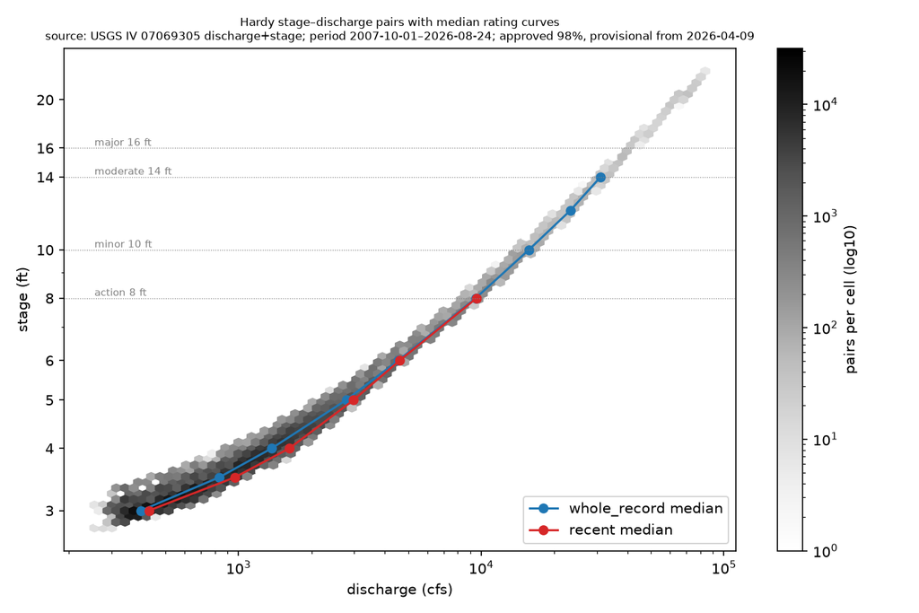

Figure 4: Hardy stage–discharge pairs (log-log hexbin density) with whole-record and recent median rating curves and NWS category stages. source: USGS IV 07069305 discharge+stage; period 2007-10-01–2026-08-24; approved 98%, provisional from 2026-04-09.

## 4.3 Post-flood base flow (Q4)

For each ≥16 ft event, mean Eckhardt base flow over 6 months starting 30 days after the event is compared with the same calendar window in the 3 non-flood years closest in standardized distance on post-window precipitation and antecedent (90-day) base flow.

Table 8: Post-flood base flow vs matched non-flood years (reports/tables/phase4_postflood_*.parquet).

| series | event_date | post_bf_cfs | pre_bf_cfs | matched_years | matched_bf_cfs | matched_pre_bf_cfs | post_p_in | matched_p_in | diff_pct |
| --- | --- | --- | --- | --- | --- | --- | --- | --- | --- |
| Mammoth | 2006-09-23 | 349.4 | 218.3 | 2004,1987,2014 | 288.9 | 227.5 | 25.3 | 26.45 | 20.97 |
| Mammoth | 2008-03-19 | 338.4 | 234.4 | 1982,2003,1990 | 268.1 | 233.2 | 26.51 | 25.64 | 26.2 |
| Mammoth | 2009-10-30 | 362.2 | 275.6 | 2021,2013,2015 | 321.1 | 270.3 | 25.01 | 25.81 | 12.79 |
| Mammoth | 2011-04-26 | 307.4 | 226 | 2000,2001,1987 | 190 | 235.9 | 23.18 | 20.94 | 61.81 |
| Mammoth | 2017-04-30 | 275.5 | 267.6 | 1999,1986,1987 | 227.6 | 292.7 | 13.97 | 17.95 | 21.05 |
| Mammoth | 2025-04-05 | 354.6 | 358.6 | 1991,1988,2019 | 313.3 | 352.5 | 24.09 | 24.99 | 13.2 |
| Hardy | 2006-09-23 | 1232 | 251.3 | 2004,2014,2003 | 912.6 | 394 | 25.3 | 23.79 | 34.98 |
| Hardy | 2008-03-19 | 787.6 | 721.8 | 2003,2004,2014 | 578.6 | 724.2 | 26.51 | 27.71 | 36.13 |
| Hardy | 2009-10-30 | 1336 | 946.4 | 2013,2020,2022 | 1055 | 508.8 | 25.01 | 23.46 | 26.69 |
| Hardy | 2011-04-26 | 698.1 | 632.4 | 2004,2014,2013 | 482.4 | 770.6 | 23.18 | 25.76 | 44.73 |
| Hardy | 2017-04-30 | 600.3 | 903.5 | 2021,2022,2014 | 564.1 | 1133 | 13.97 | 20.09 | 6.412 |
| Hardy | 2025-04-05 | 975.3 | 1271 | 2015,2002,2023 | 720.4 | 1279 | 24.09 | 25.09 | 35.38 |

- Mean difference: Mammoth +26.0% (bootstrap 95% CI 15.7 to 41; n = 6 events, 16 unique control years); Hardy +30.7% (CI 19.6 to 38.7; n = 6, 10 controls). Every event’s difference is positive. The hypothesis that major floods suppress recharge is not supported; the sign is opposite.

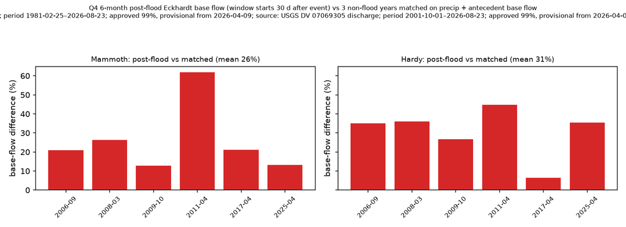

Figure 5: Q4 post-flood base flow vs matched controls. source: USGS DV 07069190 discharge; period 1981-02-25–2026-08-23; approved 99%, provisional from 2026-04-09; source: USGS DV 07069305 discharge; period 2001-10-01–2026-08-23; approved 99%, provisional from 2026-04-09; events from USGS peaks 07069305.

**Does the procedure manufacture this?** With six events, three nearest controls each and heavy control-year reuse, the machinery itself might produce a positive difference. The placebo runs the identical pipeline on 200 sets of random NON-flood pseudo-events, keeping the real events’ days-of-year so seasonality is held fixed; what it returns is what “no flood” looks like through this pipeline. The skip-day sensitivity asks whether the effect is recession water still in the post window rather than a change in base flow.

Table 9: Q4 placebo distribution and skip-day sensitivity (reports/tables/phase4_postflood_placebo.parquet, phase4_postflood_skip_days.parquet).

| series | real (%) | placebo mean (%) | placebo sd | placebo p95 | frac of trials ≥ real | placebo-corrected (%) | skip 15 d (%) | skip 30 d (%) | skip 60 d (%) | skip 90 d (%) |
| --- | --- | --- | --- | --- | --- | --- | --- | --- | --- | --- |
| Mammoth | 26 | 0.6 | 6.94 | 11.5 | 0 | 25.4 | 25.4 | 26 | 19.1 | 21.9 |
| Hardy | 30.7 | 9.73 | 17.1 | 37.7 | 0.11 | 21 | 30.6 | 30.7 | 23.9 | 8.04 |

- **Mammoth stands, and is stronger than the bootstrap CI suggests.** Its placebo is centred at +0.6% (sd 6.9) and **none** of the trials reaches the observed +26.0%; the effect holds from a 15- to a 90-day skip.
- **Hardy is materially weakened.** Its placebo is centred at +9.7% (sd 17) and 11% of trials reach or beat the observed +30.7%. Pushing the post window to 90 days after the event drops the effect to +8.0% with a CI spanning zero. About a third of the figure is procedural and part of the rest is recession water still present at 30 days: report Hardy placebo-corrected (+21%) with this sensitivity, not the raw percentage.

Limitation: the bootstrap CI reflects event-to-event variation only; matching uncertainty and control-year reuse are not propagated, which is exactly what the placebo above exists to expose. n = 6 events is the binding constraint; a dose–response regression of post-event base-flow anomaly on peak magnitude across all peaks would need no matched controls. Descriptive, not causal.

# 5 Flood regime

Thesis: flood frequency at Hardy and Imboden is stationary within the resolving power of the record — now on an upper-tail test that could have found a change rather than only a centre-of-distribution rule. At the major-exposure tier the published return periods are biased long because they exclude the known 1982 crest; with it restored, 23 ft is 20–29 yr. Return periods beyond ~50 yr are extrapolation.

## 5.1 Flood frequency (Q8)

Log-Pearson III by method of moments with Bulletin 17B weighted skew (regional skew -0.2, approximate), Grubbs-Beck low-outlier screen flagging but not dropping, and a 2,000-resample nonparametric bootstrap for the 5–95 % interval. Not EMA; the 1982 crest is not in the fit.

Table 10: LP3 fit parameters (docs/phase5_floods.md).

| series | n | wy_start | wy_end | station_skew | weighted_skew | gb_threshold_cfs | low_outliers_flagged |
| --- | --- | --- | --- | --- | --- | --- | --- |
| Hardy | 24 | 2002 | 2025 | -0.16 | -0.18 | 2969 | 0 |
| Hardy — station skew only | 24 | 2002 | 2025 | -0.16 | -0.16 | 2969 | 0 |
| Imboden | 89 | 1937 | 2025 | -0.18 | -0.18 | 2724 | 1 |
| Imboden WY <2008 | 71 | 1937 | 2007 | -0.24 | -0.23 | 2704 | 1 |
| Imboden WY ≥2008 | 18 | 2008 | 2025 | 0.28 | 0.04 | 7251 | 0 |

Table 11: LP3 discharge quantiles, cfs, with 5–95 % bootstrap bounds (reports/tables/phase5_lp3_*.parquet).

| series | return period (yr) | Q (cfs) | 5 % | 95 % |
| --- | --- | --- | --- | --- |
| Hardy | 1 | 11,288 | 8,480 | 15,771 |
| Hardy | 2 | 22,807 | 17,174 | 30,208 |
| Hardy | 5 | 44,552 | 32,553 | 57,205 |
| Hardy | 10 | 62,391 | 44,282 | 79,486 |
| Hardy | 25 | 88,469 | 60,333 | 114,284 |
| Hardy | 50 | 110,266 | 73,308 | 144,373 |
| Hardy | 100 | 133,946 | 87,021 | 179,736 |
| Imboden | 1 | 14,186 | 12,133 | 16,903 |
| Imboden | 2 | 27,522 | 23,910 | 31,286 |
| Imboden | 5 | 51,677 | 43,616 | 59,601 |
| Imboden | 10 | 70,918 | 58,308 | 84,761 |
| Imboden | 25 | 98,446 | 76,431 | 124,449 |
| Imboden | 50 | 121,050 | 89,488 | 161,724 |
| Imboden | 100 | 145,282 | 101,403 | 205,995 |

- Hardy 10-yr flood 62,391 cfs (44,282–79,486); 100-yr 133,946 cfs (87,021–179,736), a 69%-wide interval relative to the estimate. Replacing weighted skew with station skew moves the Hardy 100-yr estimate to 135,408 cfs (+1.1%).

**The 1982 crest belongs in the fit.** The 1982-12-03 29.0 ft crest is known but sits outside the systematic record, and excluding a known extreme biases the return periods of exactly the tier a reader cares most about. By the annual-peak log-log relation it is ≈156,047 cfs. Adding it back as historical information (Bulletin 17B weighting, W = (H−Z)/(n−s)) over a historical period H of 44 yr (1982–2025) and 90 yr:

Table 12: Q8 return periods with the 1982 crest as historical information (reports/tables/phase5_historical_1982.parquet).

| case | historical period (yr) | effective n | weighted skew | 16 ft (yr) | 20 ft (yr) | 23 ft (yr) |
| --- | --- | --- | --- | --- | --- | --- |
| systematic only (headline fit) | nan | 24 | -0.175 | 4.47 | 12.5 | 29.4 |
| with 1982 crest, H=44 yr | 44 | 44 | -0.0557 | 4.04 | 9.86 | 20.1 |
| with 1982 crest, H=90 yr | 90 | 90 | -0.0895 | 4.3 | 11.3 | 24.5 |

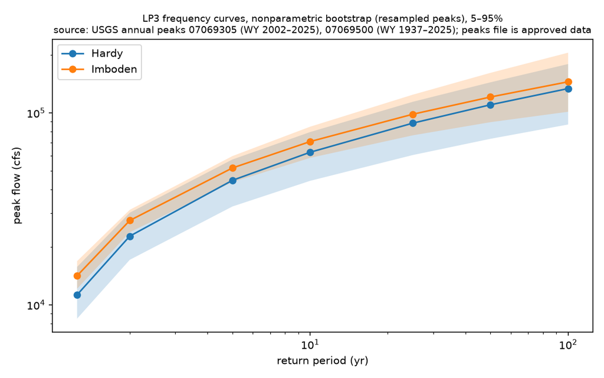

Figure 6: LP3 frequency curves with bootstrap bands; Hardy (n = 24, WY 2002–2025) and Imboden (n = 89, WY 1937–2025). Source: USGS annual peaks 07069305 and 07069500; peak files carry no provisional flag.

## 5.2 Stationarity (Q2)

- Hardy annual peaks: Sen slope 0.00125 log10-cfs/yr (95% CI -0.0232 to 0.03); MK z=0.17, p=0.862; n=24; Pettitt after WY 2011.
- Imboden annual peaks: Sen slope 0.00112 log10-cfs/yr (95% CI -0.00123 to 0.00406); MK z=0.94, p=0.346; n=89; Pettitt after WY 2005.
- Imboden LP3 split at WY 2008: 10-yr quantile 63,943 cfs (51,676–79,094, n = 71) before vs 95,546 cfs (64,510–126,275, n = 18) after; intervals overlap: yes.
- Rule: “non-stationary” requires both a trend CI excluding zero and non-overlapping split-period 10-yr CIs. **Verdict: no detectable change in flood frequency..** The post-2008 point estimate is higher; the n = 18 record cannot distinguish it from sampling variation.
- **The rule is weak, so the tail was tested directly.** A conjunction of two conditions can barely fail at any n, and both conditions inspect the centre of the distribution while a flood-risk question is about the upper tail. Quantile regression at q = 0.90 gives +0.00263 log10-cfs/yr (95 % CI -0.0017 to 0.007) and the top-quartile Sen slope +0.00081 (CI -0.00094 to 0.0039). Both CIs span zero, so the conclusion is **better supported than the conjunction rule made it look**: it now rests on a test with the power to have detected a tail change.
- **Disclosed as post hoc.** Splitting at WY 2008 gives a mean shift (Welch p = 0.028, Mann–Whitney p = 0.05) that the decision rule never surfaced. The split year was chosen after seeing the data — a split at 1980 gives p ≈ 0.77 — so this is a hypothesis for new data, not a result. It is reported because omitting it would be selective.

## 5.3 Partial-duration series and threshold counts

Events are daily-max IV stage exceedances with 7-day declustering, complete water years 2008–2025 (n = 18).

Table 13: POT event statistics by threshold (docs/phase5_floods.md). Dispersion = variance/mean of annual counts (1 under Poisson).

| threshold_ft | events | n_years | mean_per_yr | dispersion | dispersion_p | count_trend |
| --- | --- | --- | --- | --- | --- | --- |
| 8 | 45 | 18 | 2.5 | 1.24 | 0.453 | -0 events/yr (95% CI -0.0833 to 0.25); MK z=0.59, p=0.554; n=18 |
| 10 | 17 | 18 | 0.94 | 0.81 | 0.624 | -0 events/yr (95% CI -0 to 0.1); MK z=0.57, p=0.568; n=18 |
| 14 | 8 | 18 | 0.44 | 0.85 | 0.737 | -0 events/yr (95% CI -0 to -0); MK z=-0.89, p=0.373; n=18 |
| 16 | 6 | 18 | 0.33 | 1.06 | 0.778 | -0 events/yr (95% CI -0 to -0); MK z=-1.27, p=0.204; n=18 |

Table 14: POT event counts by water year (reports/tables/phase5_pot_counts.parquet). WY 2026 is partial (stage through 2026-08-24).

| WY | ≥ 8 ft | ≥ 10 ft | ≥ 14 ft | ≥ 16 ft |
| --- | --- | --- | --- | --- |
| 2008 | 2 | 2 | 2 | 2 |
| 2009 | 2 | 0 | 0 | 0 |
| 2010 | 3 | 1 | 1 | 1 |
| 2011 | 1 | 1 | 1 | 1 |
| 2012 | 1 | 0 | 0 | 0 |
| 2013 | 2 | 0 | 0 | 0 |
| 2014 | 2 | 1 | 0 | 0 |
| 2015 | 5 | 1 | 0 | 0 |
| 2016 | 5 | 2 | 1 | 0 |
| 2017 | 1 | 1 | 1 | 1 |
| 2018 | 1 | 0 | 0 | 0 |
| 2019 | 2 | 1 | 0 | 0 |
| 2020 | 4 | 0 | 0 | 0 |
| 2021 | 2 | 1 | 1 | 0 |
| 2022 | 2 | 1 | 0 | 0 |
| 2023 | 3 | 3 | 0 | 0 |
| 2024 | 0 | 0 | 0 | 0 |
| 2025 | 7 | 2 | 1 | 1 |
| 2026 | 0 | 0 | 0 | 0 |

- ≥16 ft: 6 events, 0.33/yr, dispersion 1.1 (p = 0.78); count trend -0 events/yr (95% CI -0 to -0); MK z=-1.27, p=0.204; n=18. Approved-only counts are identical.

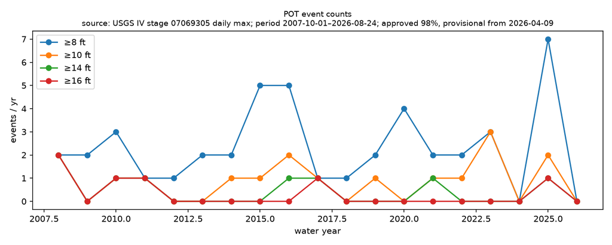

Figure 7: POT event counts per water year by threshold. Source: USGS IV stage 07069305 daily max; period 2007-10-01–2026-08-24; approved 98%, provisional from 2026-04-09.

## 5.4 Inter-arrival of major floods (Q6)

Events (annual-peak file before WY 2008; declustered daily-max stage after): 2006-09-23, 2008-03-19, 2008-04-10, 2009-10-30, 2011-04-26, 2017-04-30, 2025-04-05.

Table 15: Inter-arrival statistics of ≥16 ft events; KS distance vs an exponential fit with bootstrap p (docs/phase5_floods.md).

| series | n | mean_gap_yr | median_gap_yr | cv | ks | bootstrap_p |
| --- | --- | --- | --- | --- | --- | --- |
| 2002–present | 7 | 3.09 | 1.52 | 1.01 | 0.27 | 0.465 |
| with 1982 crest | 8 | 6.05 | 1.56 | 1.38 | 0.34 | 0.108 |

CV ≈ 1 and bootstrap p = 0.47 (n = 7) are the exponential signature: the ~4-yr cadence is modal, not periodic.

**But state what this test could have found.** At 6 gaps a memoryless process routinely produces a CV anywhere in 0.42–1.5 (central 95 %), so the observed 1.01 is unremarkable in either direction. Power against a regular (gamma) cadence is 0.23 at CV 0.7 and 0.58 at CV 0.5, reaching 80 % only at CV ≈ 0.35 — near-metronomic. The conclusion is therefore **“no cadence is detectable, and none weaker than near-metronomic could have been”**, not “the process is memoryless”. A high p here is an absence of evidence. The ≥10 ft POT series above, with real n, is the supplementary check. A spectral check on n = 7 events is not informative and was not run.

## 5.5 Quiet year after a major flood (Q7)

P(annual peak < 8 ft | prior WY had a ≥16 ft event) = 0 vs base rate 0.08; difference -0.08 (Clopper-Pearson exact 95 % bounds -0.08 to +0.44); permutation p = 1; n_major = 5, n_years = 24.

**This is untestable with the current record, which is not the same as no support.** Fisher-exact power at n_major = 5 is 0.084 against a 2.5× effect and reaches 80 % only if a quiet year followed a major flood about 80% of the time; the exact bound already admits a conditional rate anywhere from 0.00 to 0.52. The design produced **no result**, not a null result, and Q7 is reclassified accordingly. Testing it would need far more major-flood years than this river has recorded.

## 5.6 Antecedent conditions

Table 16: Antecedent 60-day BFI, 30-day basin precipitation and base flow before ≥14 ft annual peaks (docs/phase5_floods.md; windows exclude the event day).

| event_date | bfi_prior | precip_prior_in | baseflow_prior_cfs |
| --- | --- | --- | --- |
| 2003-11-18 | 0.81 | 2.78 | 383 |
| 2006-09-23 | 0.8 | 3.19 | 243 |
| 2008-03-19 | 0.51 | 5.75 | 798 |
| 2009-10-30 | 0.55 | 9.46 | 1.19e+03 |
| 2011-04-26 | 0.43 | 12 | 806 |
| 2015-12-28 | 0.54 | 8.04 | 927 |
| 2017-04-30 | 0.64 | 7.59 | 1.09e+03 |
| 2021-04-29 | 0.7 | 2.78 | 1.33e+03 |
| 2025-04-05 | 0.8 | 3.59 | 1.28e+03 |

# 6 Precipitation regime

Thesis: precipitation over the recharge area is **not becoming wetter, and no intensification is detectable** once a known discontinuity in the gridded product is allowed for. The annual total carries no significant trend and the Sep–Feb recharge-season total is flat to negative — the robust result. The apparent rise in AORC’s storm-sharpness indices is a step at the 2002 radar onset rather than a trend (§7.2), it is not reproduced at the co-located gauge over the same years, and PRISM over the same polygon shares AORC’s inputs and cannot corroborate it independently.

This reverses the second edition’s “more intense, not detectably wetter”. What follows reports the monotone-trend tests first, because they are what the earlier reading rested on, and then the tests that reinterpret them.

Indices are calendar-year: total, Sep–Feb recharge-season total, growing-season total, wet-day counts at 0.5/1/2 in, max 1- and 3-day totals, top-5-day fraction, and SDII. Trend: Sen slope per decade with 95 % CI, Mann-Kendall, Benjamini-Hochberg across the 10 indices per series; years with < 90 % daily coverage are excluded.

Table 17: Precipitation index trends, Sen slope per decade with 95 % CI and BH-adjusted p (reports/tables/phase6_index_trends.parquet).

| series | index | n (yr) | Sen slope / decade | CI lo | CI hi | MK z | p (BH) | BH-significant |
| --- | --- | --- | --- | --- | --- | --- | --- | --- |
| USC00238880 | annual total (in) | 34 | 0.758 | -1.67 | 3.5 | 0.741 | 0.801 | False |
| USC00238880 | Sep–Feb recharge-season total (in) | 30 | 0.233 | -1.58 | 1.87 | 0.357 | 0.801 | False |
| USC00238880 | growing-season total (in) | 34 | 0.9 | -0.767 | 2.68 | 1.1 | 0.801 | False |
| USC00238880 | days ≥ 0.5 in | 34 | 0.75 | -0.789 | 2.08 | 0.954 | 0.801 | False |
| USC00238880 | days ≥ 1 in | 34 | -0 | -0.769 | 1.21 | 0.374 | 0.801 | False |
| USC00238880 | days ≥ 2 in | 34 | -0 | -0.476 | 0.455 | 0 | 1 | False |
| USC00238880 | max 1-day (in) | 34 | 0.2 | -0.1 | 0.494 | 1.19 | 0.801 | False |
| USC00238880 | max 3-day (in) | 34 | 0.508 | 0.0722 | 0.91 | 2.49 | 0.127 | False |
| USC00238880 | top-5-day fraction of annual | 34 | 0.00183 | -0.00612 | 0.0113 | 0.563 | 0.801 | False |
| USC00238880 | SDII (in/wet day) | 34 | 0.00432 | -0.0133 | 0.019 | 0.534 | 0.801 | False |
| KUNO | annual total (in) | 27 | 4.28 | -0.557 | 10.3 | 1.71 | 0.226 | False |
| KUNO | Sep–Feb recharge-season total (in) | 27 | 1.52 | -0.596 | 3.35 | 1.63 | 0.226 | False |
| KUNO | growing-season total (in) | 27 | 3.4 | -1.08 | 7.13 | 1.58 | 0.226 | False |
| KUNO | days ≥ 0.5 in | 27 | 3.33 | -0 | 7.5 | 1.86 | 0.226 | False |
| KUNO | days ≥ 1 in | 27 | 1.43 | -0.769 | 3.08 | 1.3 | 0.277 | False |
| KUNO | days ≥ 2 in | 27 | 0.455 | -0 | 1.25 | 1.41 | 0.262 | False |
| KUNO | max 1-day (in) | 27 | 0.25 | -0.21 | 0.75 | 1.21 | 0.283 | False |
| KUNO | max 3-day (in) | 27 | 0.4 | -0.562 | 1.44 | 0.709 | 0.532 | False |
| KUNO | top-5-day fraction of annual | 27 | -0.00291 | -0.0241 | 0.0188 | -0.208 | 0.835 | False |
| KUNO | SDII (in/wet day) | 27 | 0.0634 | 0.033 | 0.09 | 3.38 | 0.00732 | True |
| USC00230127 | annual total (in) | 24 | 2.17 | -2.13 | 6.6 | 1.07 | 0.515 | False |
| USC00230127 | Sep–Feb recharge-season total (in) | 21 | 0.678 | -1.32 | 2.72 | 0.876 | 0.545 | False |
| USC00230127 | growing-season total (in) | 24 | 1.6 | -1.34 | 4.35 | 1.22 | 0.515 | False |
| USC00230127 | days ≥ 0.5 in | 24 | 0.801 | -1.54 | 3.48 | 0.774 | 0.549 | False |
| USC00230127 | days ≥ 1 in | 24 | 1.25 | -0.769 | 3.33 | 1.08 | 0.515 | False |
| USC00230127 | days ≥ 2 in | 24 | -0 | -0.455 | 0.667 | 0.484 | 0.691 | False |
| USC00230127 | max 1-day (in) | 24 | 0.0657 | -0.485 | 0.489 | 0.397 | 0.691 | False |
| USC00230127 | max 3-day (in) | 24 | 0.412 | -0.25 | 1.08 | 1.36 | 0.515 | False |
| USC00230127 | top-5-day fraction of annual | 24 | -0.0106 | -0.0268 | 0.0098 | -1.12 | 0.515 | False |
| USC00230127 | SDII (in/wet day) | 24 | 0.0216 | -0.0275 | 0.07 | 1.02 | 0.515 | False |
| West Plains 1948– | annual total (in) | 76 | 1.26 | 0.282 | 2.34 | 2.47 | 0.0673 | False |
| West Plains 1948– | Sep–Feb recharge-season total (in) | 74 | 0.566 | -0.0623 | 1.08 | 1.73 | 0.167 | False |
| West Plains 1948– | growing-season total (in) | 76 | 0.619 | -0.0506 | 1.31 | 1.83 | 0.167 | False |
| West Plains 1948– | days ≥ 0.5 in | 76 | 0.818 | -0 | 1.53 | 2.18 | 0.0967 | False |
| West Plains 1948– | days ≥ 1 in | 76 | 0.703 | 0.256 | 1.15 | 3.15 | 0.0166 | True |
| West Plains 1948– | days ≥ 2 in | 76 | -0 | -0 | 0.323 | 1.58 | 0.19 | False |
| West Plains 1948– | max 1-day (in) | 76 | 0.0331 | -0.0851 | 0.149 | 0.529 | 0.597 | False |
| West Plains 1948– | max 3-day (in) | 76 | 0.065 | -0.105 | 0.235 | 0.789 | 0.537 | False |
| West Plains 1948– | top-5-day fraction of annual | 76 | -0.00277 | -0.00681 | 0.00133 | -1.39 | 0.233 | False |
| West Plains 1948– | SDII (in/wet day) | 76 | 0.0028 | -0.00492 | 0.00999 | 0.637 | 0.582 | False |
| basin | annual total (in) | 45 | 0.96 | -1.25 | 3.12 | 0.851 | 0.395 | False |
| basin | Sep–Feb recharge-season total (in) | 44 | -0.806 | -1.99 | 0.602 | -1.16 | 0.306 | False |
| basin | growing-season total (in) | 45 | 1.46 | 0.207 | 2.9 | 2.18 | 0.0486 | True |
| basin | days ≥ 0.5 in | 45 | 1.74 | -0 | 3.33 | 2.05 | 0.0577 | False |
| basin | days ≥ 1 in | 45 | 1.38 | 0.488 | 2.22 | 2.95 | 0.016 | True |
| basin | days ≥ 2 in | 45 | 0.286 | -0 | 0.625 | 2.18 | 0.0486 | True |
| basin | max 1-day (in) | 45 | 0.264 | 0.0517 | 0.495 | 2.36 | 0.046 | True |
| basin | max 3-day (in) | 45 | 0.147 | -0.12 | 0.534 | 1.09 | 0.308 | False |
| basin | top-5-day fraction of annual | 45 | 0.00988 | 0.00264 | 0.0177 | 2.51 | 0.0398 | True |
| basin | SDII (in/wet day) | 45 | 0.0324 | 0.0204 | 0.0461 | 4.37 | 0.000123 | True |

- Basin (AORC, MoDNR polygon, n = 45 years): 6/10 indices BH-significant: intensity (max 1-day, SDII, top-5 share), wet-day counts (≥ 1 in, ≥ 2 in) and the growing-season total; not the annual or recharge-season totals. The annual total is **not** among them: +0.96 in/decade (95 % CI -1.2 to 3.1; mean 47.5 in), a CI spanning zero. Days ≥ 1 in +1.38/decade (CI 0.49 to 2.2); max 1-day +0.264 in/decade (CI 0.052 to 0.49); SDII +0.0324 in/wet-day/decade (CI 0.02 to 0.046).
- Recharge season (Sep–Feb, 47% of the annual mean): -0.806 in/decade (CI -2 to 0.6, n = 44) — flat to negative, and the only rise in a seasonal total is the growing season. Nothing here adds water to the recharge season.
- Stations: USC00238880 0/10 significant (n = 34; max 3-day +0.508 in/decade, CI 0.072 to 0.91, p_BH = 0.13); KUNO 1/10 (SDII +0.0634, CI 0.033 to 0.09, n = 27); Alton USC00230127 0/10 (n = 24 years — no data 1983–1994 or 2012–2016, a consistency check only). USC00238880 fails the coverage gate in 11 years, 10 of them in 2011–2021 (2011, 2012, 2013, 2014, 2015, 2016, 2017, 2019, 2020, 2021), which removes most of the recent wet decade from the station test; its null is low power, not evidence against the basin trend.
- **West Plains 1948–** (1949–2025, n = 76 years): two instruments, one at a time — the town COOP gauge through 1998-03-31, then the KUNO airport ASOS (10.7 mi north, 120 ft higher) from 1998-04-01, raised by the COOP/KUNO catch ratio 1.068 measured on 282 overlapping months so the record stays on the town gauge’s level (10,331 KUNO days and 43 days KUNO missed after 1998-04-01; no day is borrowed between gauges and none is interpolated). 76 years pass the coverage gate against 34 for COOP alone, making this the longest and highest-power station test in the study. 1/10 indices are BH-significant (days ≥ 1 in). The annual total rises +1.26 in/decade (95 % CI 0.28 to 2.3, n = 76) but does not survive BH correction; the recharge-season total is +0.566 in/decade (CI -0.062 to 1.1, n = 74). Unlike the basin series, the gauge record shows no intensification: max 1-day +0.0331 in/decade (CI -0.085 to 0.15) and SDII +0.0028 in/wet-day/decade (CI -0.0049 to 0.01) both have CIs spanning zero over 76 years. What it does show is more wet days: days ≥ 1 in +0.703/decade (CI 0.26 to 1.2), the one index that passes — **but that result is knife-edge on the catch ratio.** The whole KUNO era is scaled by one constant measured on the period it is applied to, so an error in it maps one-for-one into the trend. Which indices pass BH at each ratio: 1.000 → no index passes BH at q=0.05; 1.034 → no index passes BH at q=0.05; 1.068 (the measured value) → days_ge_1; 1.100 → total_in, days_ge_1. A residual step term at the 1998 instrument change is also significant for SDII (-0.0557, p = 0.044) and for the recharge-season total (-5.16 in, p = 0.043), and allowing it reveals an SDII trend of +0.0137/decade (p = 0.042) that the pooled fit suppresses — KUNO’s tipping bucket counts more small events than a volunteer observer, deflating KUNO-era SDII. The COOP-only era (1949–1997) is the homogeneous baseline. Read “more wet days, not harder rain” as resting on a splice, not as established.

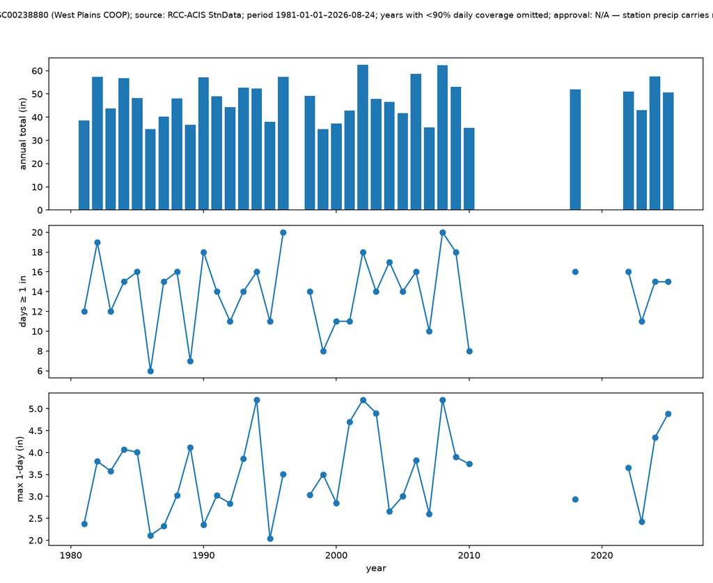

Figure 8: annual total, days ≥ 1 in, and max 1-day precip at USC00238880; source RCC-ACIS StnData; period 1981-01-01–2026-08-24; years with <90% daily coverage omitted; approval N/A — station precip carries no approval flag.

## 6.1 Is the intensity signal a trend or a 2002 product change?

AORC v1.1 blends gauges and reanalysis throughout but gains radar (Stage IV/MRMS) input only from 2002. A gauge/reanalysis blend is smooth; a radar-informed analysis is sharp. Every index flagged above measures sharpness, and a monotone-trend test on a series with an input change at 2002 reads the step as a trend. Three tests separate them.

**A step term absorbs the trend.** Refitting each index as OLS `index ~ year + I(year ≥ 2002)` with HC3 errors:

Table 18: Basin index trends with a 2002 step term (reports/tables/phase6_step_2002.parquet). `slope_per_decade` is the trend surviving once the step is allowed for; `step` is the level shift in the index’s own units.

| index | n | slope/decade | CI lo | CI hi | slope p | step | step p | step BH-sig |
| --- | --- | --- | --- | --- | --- | --- | --- | --- |
| annual total (in) | 45 | -2.12 | -5.52 | 1.28 | 0.222 | 9.34 | 0.0432 | False |
| Sep–Feb recharge-season total (in) | 44 | -2.09 | -4.58 | 0.409 | 0.101 | 3.61 | 0.25 | False |
| growing-season total (in) | 45 | 0.0484 | -2.73 | 2.83 | 0.973 | 5.53 | 0.196 | False |
| days ≥ 0.5 in | 45 | 0.19 | -2.14 | 2.52 | 0.873 | 4.66 | 0.109 | False |
| days ≥ 1 in | 45 | -0.932 | -2.37 | 0.502 | 0.203 | 6.9 | 0.000302 | True |
| days ≥ 2 in | 45 | -0.432 | -1.06 | 0.197 | 0.178 | 2.47 | 0.00655 | True |
| max 1-day (in) | 45 | -0.0225 | -0.48 | 0.435 | 0.923 | 0.86 | 0.12 | False |
| max 3-day (in) | 45 | -0.0902 | -0.904 | 0.724 | 0.828 | 1.08 | 0.272 | False |
| top-5-day fraction of annual | 45 | 0.00342 | -0.00894 | 0.0158 | 0.588 | 0.022 | 0.121 | False |
| SDII (in/wet day) | 45 | -0.00224 | -0.0272 | 0.0227 | 0.86 | 0.114 | 0.000966 | True |

SDII’s slope collapses to -0.002/decade (p = 0.86) while its step is significant (+0.114, p = 0.00097); days ≥ 1 in goes to -0.932/decade (p = 0.2) with step p = 0.0003; max 1-day to -0.0225 (p = 0.92). The annual total is unaffected either way, which is why it remains the one Q3 result to state without qualification.

**Within each era the indices are flat or falling.** Sen slopes computed separately either side of 2002:

Table 19: Within-era Sen slopes per decade, split at 2002 (reports/tables/phase6_era_slopes.parquet).

| era | index | n (yr) | Sen slope / decade | CI lo | CI hi | p |
| --- | --- | --- | --- | --- | --- | --- |
| 1981–2001 | annual total (in) | 21 | -3.94 | -10.5 | 3.44 | 0.349 |
| 1981–2001 | Sep–Feb recharge-season total (in) | 20 | -2.26 | -7.26 | 3.31 | 0.315 |
| 1981–2001 | growing-season total (in) | 21 | -1.07 | -3.37 | 1.38 | 0.526 |
| 1981–2001 | days ≥ 0.5 in | 21 | -0 | -5 | 5 | 1 |
| 1981–2001 | days ≥ 1 in | 21 | -0 | -2.5 | 2.63 | 0.855 |
| 1981–2001 | days ≥ 2 in | 21 | -0 | -0 | 0.556 | 0.922 |
| 1981–2001 | max 1-day (in) | 21 | 0.0707 | -0.694 | 0.672 | 0.786 |
| 1981–2001 | max 3-day (in) | 21 | -0.0991 | -0.702 | 0.751 | 0.833 |
| 1981–2001 | top-5-day fraction of annual | 21 | 0.0203 | -0.00705 | 0.0455 | 0.124 |
| 1981–2001 | SDII (in/wet day) | 21 | 0.00792 | -0.0248 | 0.0416 | 0.695 |
| 2002–2025 | annual total (in) | 24 | -1.58 | -7.62 | 4.95 | 0.568 |
| 2002–2025 | Sep–Feb recharge-season total (in) | 24 | -1.32 | -4.99 | 1.85 | 0.413 |
| 2002–2025 | growing-season total (in) | 24 | 1.23 | -4.54 | 5.28 | 0.747 |
| 2002–2025 | days ≥ 0.5 in | 24 | -0 | -3.64 | 5 | 1 |
| 2002–2025 | days ≥ 1 in | 24 | -1.35 | -4 | 0.769 | 0.185 |
| 2002–2025 | days ≥ 2 in | 24 | -0 | -1.67 | -0 | 0.243 |
| 2002–2025 | max 1-day (in) | 24 | -0.0568 | -0.613 | 0.675 | 0.862 |
| 2002–2025 | max 3-day (in) | 24 | -0.291 | -0.911 | 0.999 | 0.503 |
| 2002–2025 | top-5-day fraction of annual | 24 | -0.0119 | -0.0267 | 0.00622 | 0.224 |
| 2002–2025 | SDII (in/wet day) | 24 | -0.00737 | -0.0513 | 0.0338 | 0.637 |

Not one sharpness index has a CI excluding zero on the rising side in either era. A quantity that steps once and is flat on both sides of the step is not intensifying.

**The gauge does not move with the product.** Comparing pre- and post-2002 means over the calendar years both series cover — so this is not a comparison of different periods:

Table 20: Pre/post-2002 means of each index, AORC vs the West Plains gauge, over identical years (reports/tables/phase6_era_means.parquet).

| series | index | n pre | n post | pre-2002 mean | 2002+ mean | % change |
| --- | --- | --- | --- | --- | --- | --- |
| AORC basin | annual total (in) | 20 | 24 | 45.5 | 49.7 | 9.26 |
| AORC basin | Sep–Feb recharge-season total (in) | 19 | 24 | 22.4 | 21.7 | -3.19 |
| AORC basin | growing-season total (in) | 20 | 24 | 22.7 | 28.2 | 24.5 |
| AORC basin | days ≥ 0.5 in | 20 | 24 | 28 | 32.7 | 16.8 |
| AORC basin | days ≥ 1 in | 20 | 24 | 8.15 | 12.8 | 56.4 |
| AORC basin | days ≥ 2 in | 20 | 24 | 1 | 2.5 | 150 |
| AORC basin | max 1-day (in) | 20 | 24 | 2.43 | 3.26 | 34.5 |
| AORC basin | max 3-day (in) | 20 | 24 | 3.82 | 4.69 | 22.6 |
| AORC basin | top-5-day fraction of annual | 20 | 24 | 0.192 | 0.223 | 16.1 |
| AORC basin | SDII (in/wet day) | 20 | 24 | 0.294 | 0.4 | 35.9 |
| West Plains 1948– | annual total (in) | 20 | 24 | 45.7 | 50.6 | 10.6 |
| West Plains 1948– | Sep–Feb recharge-season total (in) | 18 | 24 | 22.3 | 21.1 | -5.52 |
| West Plains 1948– | growing-season total (in) | 20 | 24 | 23.2 | 29.6 | 27.6 |
| West Plains 1948– | days ≥ 0.5 in | 20 | 24 | 30.6 | 33.5 | 9.43 |
| West Plains 1948– | days ≥ 1 in | 20 | 24 | 13.5 | 16 | 18.2 |
| West Plains 1948– | days ≥ 2 in | 20 | 24 | 3.05 | 3.75 | 23 |
| West Plains 1948– | max 1-day (in) | 20 | 24 | 3.18 | 3.69 | 16.1 |
| West Plains 1948– | max 3-day (in) | 20 | 24 | 4.12 | 5.39 | 30.6 |
| West Plains 1948– | top-5-day fraction of annual | 20 | 24 | 0.251 | 0.247 | -1.74 |
| West Plains 1948– | SDII (in/wet day) | 20 | 24 | 0.431 | 0.437 | 1.36 |

The two products agree closely on **how much rain fell** (annual total +9% in AORC vs +11% at the gauge) and disagree sharply on **how it fell**: SDII +36% vs +1%, days ≥ 1 in +56% vs +18%, max 1-day +34% vs +16%. A meteorological change would move both. A change in how the product resolves storms moves only the grid.

**The “6/10 indices” count overstates the evidence.** The ten indices are strongly correlated, and BH assumes far more independence than they have. Permuting year labels *jointly* across all ten (5,000 draws, seed 0) gives a family-wise max-T test: 2 of 10 survive (days ≥ 1 in, SDII (in/wet day)), against 6/10 under BH. The count is no longer used as a summary anywhere in this report — and under the step test above, none of the survivors is a trend.

**What would settle it.** NOAA’s AORC v1.1 homogeneity documentation; a one-cell AORC re-pull at the gauge coordinate split at 2002 (the cache keeps only the polygon mean); or an independent gridded product with no 2002 input change (nClimGrid-Daily, Livneh). PRISM cannot serve: it shares the same Stage IV/MRMS and gauge inputs.

## 6.2 What changed with the polygon and AORC

The first edition averaged PRISM over a 30 km buffer around West Plains. This edition uses the MoDNR recharge polygon and AORC; Table 21 repeats four precipitation-dependent results under all three basin series (same code, all-data variant): Q1 attribution, Q4 post-flood base flow, the Q3 intensity indices, and the precipitation→spring coupling. The annual ledger’s `precip_recharge_in` and Phase 5’s antecedent-conditions table run on the default source only. AORC and PRISM annual totals over the polygon agree (r = 0.966, ratio PRISM/AORC = 1.01, n = 45 years).

Table 21: Precipitation-dependent results by basin source (reports/tables/precip_source_comparison.parquet). Cells: estimate (95 % CI; n).

| block | metric | aorc | prism_polygon | prism_buffer |
| --- | --- | --- | --- | --- |
| q1_mammoth | p_trailing_in coef (log-cfs/in) | 0.0156 (0.0111 to 0.0201; n=42) | 0.0139 (0.00912 to 0.0186; n=42) | 0.013 (0.00893 to 0.0171; n=42) |
| q1_mammoth | OLS R² | 0.577 (n=42) | 0.519 (n=42) | 0.446 (n=42) |
| q1_mammoth | residual trend (log-cfs/yr) | -0.00126 (-0.00326 to 0.00122; n=42) | -0.00225 (-0.0048 to 0.000148; n=42) | -0.00222 (-0.00497 to 0.000453; n=42) |
| q4_mammoth | post-flood base-flow diff (%) | 26 (15.7 to 41; n=6) | 24.7 (16.5 to 35.4; n=6) | 27.5 (19.8 to 42; n=6) |
| q1_hardy | p_trailing_in coef (log-cfs/in) | 0.0231 (0.00876 to 0.0375; n=24) | 0.0246 (0.00567 to 0.0435; n=24) | 0.023 (0.00967 to 0.0363; n=24) |
| q1_hardy | OLS R² | 0.408 (n=24) | 0.553 (n=24) | 0.47 (n=24) |
| q1_hardy | residual trend (log-cfs/yr) | 0.0203 (0.00915 to 0.0291; n=24) | 0.0103 (-0.00061 to 0.0191; n=24) | 0.00676 (-0.00135 to 0.0195; n=24) |
| q4_hardy | post-flood base-flow diff (%) | 30.7 (19.6 to 38.7; n=6) | 32.9 (24 to 41.5; n=6) | 22.9 (12.6 to 35.1; n=6) |
| q3 | total_in slope/decade | 0.96 (-1.25 to 3.12; n=45) | 2.01 (-0.0612 to 4.2; n=45) | 2.41 (0.355 to 4.46; n=45) |
| q3 | total_in BH-significant | no | no | yes |
| q3 | recharge_in slope/decade | -0.806 (-1.99 to 0.602; n=44) | -0.282 (-1.51 to 1.04; n=44) | -0.0177 (-1.27 to 1.19; n=44) |
| q3 | recharge_in BH-significant | no | no | no |
| q3 | max1_in slope/decade | 0.264 (0.0517 to 0.495; n=45) | 0.28 (0.082 to 0.481; n=45) | 0.28 (0.0967 to 0.528; n=45) |
| q3 | max1_in BH-significant | yes | yes | yes |
| q3 | sdii_in slope/decade | 0.0324 (0.0204 to 0.0461; n=45) | 0.0217 (0.00838 to 0.0358; n=45) | 0.0347 (0.0222 to 0.0486; n=45) |
| q3 | sdii_in BH-significant | yes | yes | yes |
| coupling | response lag (months) | 1 (n=539) | 1 (n=545) | 1 (n=545) |
| coupling | r at response lag | 0.454 (0.412 to 0.519; n=539) | 0.476 (0.437 to 0.54; n=545) | 0.463 (0.422 to 0.526; n=545) |

Two conclusions appeared to move between editions, and Phase 8 shows both readings were wrong. **The annual-total trend was not a property of the buffer geometry.** The buffer and polygon annual totals correlate r = 0.984, and the trend of their *difference* is +0.272 in/decade (95 % CI -0.091 to 0.68, n = 45) — no detectable difference in how the two geometries evolve. The first edition’s significance and this edition’s null are the same estimate either side of a p-value threshold; both geometries give a positive annual-total slope not separable from zero at this n. **And the Hardy residual is not source-dependent**: dropping the never-significant ENSO term makes it significant on all three sources, and the Hardy/Mammoth ratio establishes the rise with no precipitation model at all (§4.1). What genuinely differs by source is the Mammoth residual, which is marginally negative on the PRISM fits (§4.1). Everything else held: the post-flood base-flow gain stays positive at both gauges, and the precipitation→spring coupling is a 1-month lag at r ≈ 0.45 regardless of source. The intensity indices rise on all three sources — which, given that all three share radar and gauge inputs, is now read as evidence about the products rather than about the weather.

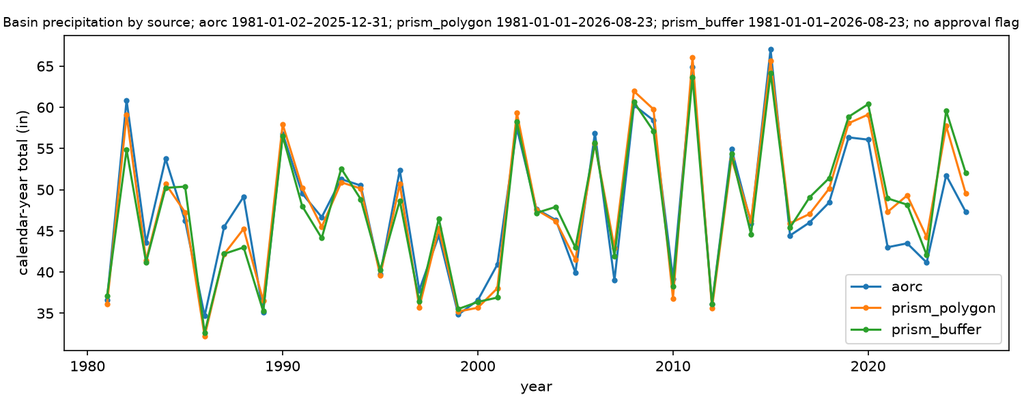

Figure 9: Calendar-year basin precipitation under the three sources; period 1981–present; no approval flag applies.

## 6.3 Seasonality and recession

Thesis: floods arrive in late winter–early spring at every gauge and in every decade with enough events to test, and no drift is detectable on the long record (now tested, not asserted); post-peak recession is fast at Hardy (k ≈ 14 days) and slow at Mammoth Spring (k ≈ 188 days), and neither constant trends with water year.

Peak timing is the circular mean of day-of-year per calendar decade; R is the mean resultant length (0 = uniform through the year, 1 = every peak on the same day); the Rayleigh test is of uniformity (Zar approximation, adequate for n ≥ 3, blank below). Decades are calendar decades, so the first row of each series is partial.

Table 22: Peak timing by calendar decade (reports/tables/phase7_peak_timing.parquet). Hardy POT events are the day of the 7-day-declustered daily-max IV stage ≥ 10 ft; annual peaks from the USGS peaks files.

| series | period | n | mean date | R | Rayleigh p |
| --- | --- | --- | --- | --- | --- |
| Hardy POT ≥10 ft events (WY 2008+) | 2000–2009 | 3 | 06 Mar | 0.402 | 0.651 |
| Hardy POT ≥10 ft events (WY 2008+) | 2010–2019 | 7 | 10 Feb | 0.545 | 0.125 |
| Hardy POT ≥10 ft events (WY 2008+) | 2020–2029 | 7 | 20 Mar | 0.643 | 0.050 |
| Hardy POT ≥10 ft events (WY 2008+) | all | 17 | 03 Mar | 0.534 | 0.006 |
| Hardy annual peaks (WY 2002+) | 2000–2009 | 9 | 10 Jan | 0.433 | 0.188 |
| Hardy annual peaks (WY 2002+) | 2010–2019 | 9 | 26 Feb | 0.620 | 0.027 |
| Hardy annual peaks (WY 2002+) | 2020–2029 | 6 | 30 Apr | 0.687 | 0.053 |
| Hardy annual peaks (WY 2002+) | all | 24 | 03 Mar | 0.426 | 0.011 |
| Imboden annual peaks (WY 1937+) | 1930–1939 | 3 | 12 Feb | 0.939 | 0.058 |
| Imboden annual peaks (WY 1937+) | 1940–1949 | 10 | 02 Mar | 0.679 | 0.007 |
| Imboden annual peaks (WY 1937+) | 1950–1959 | 10 | 27 Feb | 0.586 | 0.028 |
| Imboden annual peaks (WY 1937+) | 1960–1969 | 10 | 09 Apr | 0.501 | 0.079 |
| Imboden annual peaks (WY 1937+) | 1970–1979 | 11 | 09 Feb | 0.389 | 0.191 |
| Imboden annual peaks (WY 1937+) | 1980–1989 | 9 | 18 Jan | 0.680 | 0.012 |
| Imboden annual peaks (WY 1937+) | 1990–1999 | 10 | 28 Mar | 0.309 | 0.394 |
| Imboden annual peaks (WY 1937+) | 2000–2009 | 11 | 16 Jan | 0.329 | 0.311 |
| Imboden annual peaks (WY 1937+) | 2010–2019 | 9 | 27 Feb | 0.645 | 0.019 |
| Imboden annual peaks (WY 1937+) | 2020–2029 | 6 | 13 Mar | 0.701 | 0.045 |
| Imboden annual peaks (WY 1937+) | all | 89 | 24 Feb | 0.487 | 0.000 |

- Whole series: Imboden annual peaks n = 89, mean date 24 Feb, R = 0.49, Rayleigh p = 0.0000; Hardy annual peaks n = 24, mean date 03 Mar, R = 0.43, Rayleigh p = 0.0115; Hardy POT ≥ 10 ft events n = 17, mean date 03 Mar, R = 0.53, Rayleigh p = 0.0062. All three reject uniformity; R ≈ 0.4–0.5 means a broad late-winter mode, not a narrow one.
- Decades: Imboden decade means range from 16 Jan (2000–2009) to 09 Apr (1960–1969) with no monotone ordering across the 10 decades; the 2020s rows sit inside the spread of earlier decades. Per-decade Rayleigh tests at n ≤ 11 have little power and are reported, not interpreted.
- **“No drift” is now tested, not asserted.** Watson–Williams across decades does not reject a common circular mean on the long Imboden series (F = 1.17, p = 0.32, 10 decades, n = 89) — the only series with enough decades to speak to a century-scale drift. It **does** reject on the 3-decade Hardy annual-peak series (p = 0.0266), which is a difference among three decade means, not a direction of travel. Either way a decade mean’s circular standard error is about 21 days, so only a large drift would be detectable.

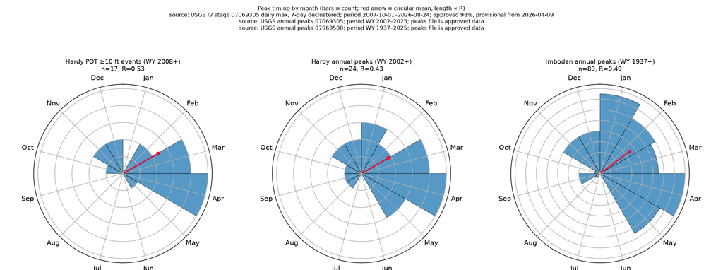

Recession constant k (days) is from OLS ln q = a − t/k on each recession run after the quickflow crest (Hardy: min peak 10,000 cfs, skip 3 days, ≥10-day runs, ≤2% daily rise; Mammoth Spring: min peak 488 cfs, skip 3 days, ≥10-day runs, ≤2% daily rise); runs are extracted only within gap-free segments. Trend: Mann-Kendall / Sen on k vs water year of the peak, recomputed here from the per-event tables. **Read these trends against their effective n**: events cluster within wet years, so the event count overstates independence — 11 water-year blocks carry Hardy’s 16 fitted events and 32 carry Mammoth’s 80.

- Hardy: 16 events (k fitted for 16), median k 13.9 days (IQR 13.0–17.4), median r² 0.953. Trend Sen slope 0.0618 days/yr (95% CI -0.215 to 0.401); MK z=0.50, p=0.620; n=16. Pettitt change-point after 2015-12-28 (WY 2016; K = 42, p = 0.176) — not significant.
- Mammoth Spring: 81 events (k fitted for 80), median k 188.0 days (IQR 150.0–231.5), median r² 0.978. Trend Sen slope 0.216 days/yr (95% CI -1.03 to 1.7); MK z=0.41, p=0.681; n=80 (effective n 32 WY blocks). Pettitt after 2016-06-05 (WY 2016; K = 336, p = 0.541) — not significant. 7 of these fits have r² < 0.75 and are flagged in the phase table; a single-exponential curve describes them poorly and their long k inflates the IQR above. The spring drains an order of magnitude more slowly than the river: a Hardy crest is back on its base-flow floor in weeks, the Mammoth response persists for months (§7 lag structure).
- Approved-only: identical event sets and identical trends — no qualifying peak falls in the provisional period (from 2026-04-09); recession runs were re-extracted within approved-only gap-free segments.

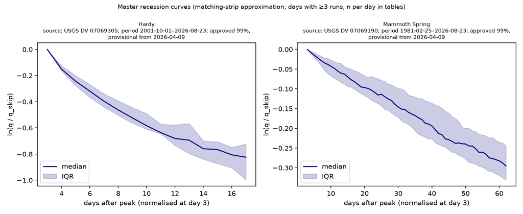

Figure 11: Master recession curves: median ln(q/q₀) by day after the skip window, IQR band, truncated at the last day reached by ≥ 3 runs (Hardy day 17, Mammoth Spring day 62). Hardy: source: USGS DV discharge 07069305; period 2001-10-01–2026-08-23; approved 99%, provisional from 2026-04-09. Mammoth Spring: source: USGS DV discharge 07069190; period 1981-02-25–2026-08-23; approved 99%, provisional from 2026-04-09.

Limitation: Hardy POT events use daily-max IV stage, an upper bound relative to a daily-mean product; k depends on the min-peak and skip choices and a single-exponential fit ignores multi-store behaviour (r² per event in the tables); the k trend treats each event as a sample although events cluster within wet years, so n overstates independence; the Rayleigh test is of uniformity only, so a bimodal spring/autumn pattern can give low R without being uniform; master curves are unweighted medians and the late IQR band rests on few long runs.

# 7 Coupling

Monthly anomalies (climatology removed; log flow) of basin precipitation vs Mammoth Spring discharge, lags 0–12 months, 1000-resample 12-month block bootstrap for the CI.

Table 23: Lag correlation, basin precipitation → Mammoth Spring flow, all data (reports/tables/phase6_lag_correlation.parquet).

| lag (months) | r | 95 % lo | 95 % hi | n (months) |
| --- | --- | --- | --- | --- |
| 0.000 | 0.288 | 0.237 | 0.344 | 538.000 |
| 1.000 | 0.454 | 0.412 | 0.519 | 539.000 |
| 2.000 | 0.340 | 0.274 | 0.397 | 540.000 |
| 3.000 | 0.267 | 0.180 | 0.329 | 540.000 |
| 4.000 | 0.209 | 0.133 | 0.256 | 540.000 |
| 5.000 | 0.152 | 0.061 | 0.203 | 540.000 |
| 6.000 | 0.140 | 0.050 | 0.199 | 540.000 |
| 7.000 | 0.101 | 0.021 | 0.166 | 540.000 |
| 8.000 | 0.062 | -0.029 | 0.145 | 539.000 |
| 9.000 | 0.015 | -0.087 | 0.094 | 538.000 |
| 10.000 | 0.007 | -0.068 | 0.087 | 537.000 |
| 11.000 | 0.047 | -0.033 | 0.132 | 536.000 |
| 12.000 | 0.009 | -0.080 | 0.108 | 535.000 |

- Response peaks at lag 1 month: r = 0.45 (95 % CI 0.41 to 0.52, n = 539), vs r = 0.29 at lag 0. Correlation decays to a CI including zero by lag 8: the spring integrates roughly two seasons of rainfall.
- **The 1-month lag is a bin, not a transit time.** At daily resolution the cross-correlation peaks at 2 days (r = 0.14) and decays monotonically thereafter, with no local maximum near 30 days. The honest statement carries both halves: **onset within days; monthly correlation maximised at lag 1 month.** The monthly figure is the coarsest bin that captures a fast onset plus a long tail, and reading it as an aquifer travel time would be wrong.
- Approved-only flow: lag 1, r = 0.45 (CI 0.41 to 0.52, n = 539) — unchanged.
- Spring → river: Hardy min7 is set by Mammoth base flow plus tributary inflow; the Hardy attribution model (§4.1) uses the same trailing-365-day precipitation window and reaches R² = 0.41.

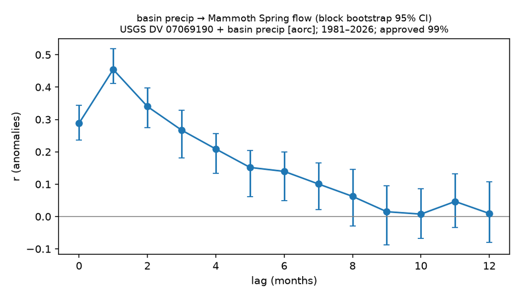

Figure 12: source: USGS DV 07069190 + NOAA AORC v1.1 1 km hourly basin mean over the MoDNR Mammoth Spring recharge polygon (~349 mi²), daily totals 24 h ending 12 UTC; period 1981-02-25–2026-08-23; approved 99%, provisional from 2026-04-09.

# 8 Synthesis

Table 24: Working hypotheses (plan.md §0) vs results. Every number regenerated from reports/tables/ or parsed from the phase reports.

[output not shown]

# 9 Practical thresholds

Table 25: Stage return periods at Hardy (reports/tables/phase5_return_periods_stage.parquet). Stage→flow: log10 Q = a + b·log10 H fitted to the annual-peak pairs; NWS crest count includes the 1982-12-03 29.0 ft record.

| stage (ft) | flow (cfs) | LP3 return period (yr) | annual-peak exceedances WY 2002–2025 | empirical return period (yr) | NWS crests ≥ stage 1982–2025 |
| --- | --- | --- | --- | --- | --- |
| 8.0 | 9,000.8 | 1.2 | 22 | 1.1 | 21 |
| 10.0 | 14,755.6 | 1.4 | 16 | 1.5 | 20 |
| 14.0 | 31,092.6 | 2.9 | 9 | 2.7 | 11 |
| 16.0 | 41,794.6 | 4.5 | 6 | 4.0 | 8 |
| 20.0 | 68,516.4 | 12.5 | 3 | 8.0 | 5 |
| 23.0 | 93,379.5 | 29.4 | 0 | >24 | 1 |

Stage→flow: log10 Q = 1.954 + 2.215·log10 H (R² = 0.991, n = 24 annual-peak pairs). Rating drift (§4.2) propagates into this mapping.

| Band | Stage at Hardy | Basis | Expected recurrence |
| --- | --- | --- | --- |
| Paddling, low | below the 400 cfs stage (2.95 ft in WY 2026) | stage-at-flow fit, drifting 0.08 ft/decade | typical late-summer base flow (min7 348 cfs median WY 2002–2025) |
| Paddling, runnable | 400–1000 cfs (2.95–3.56 ft) | stage-at-flow fit | most of the year; Mammoth supplies ≥ 174 cfs (record min7) |
| Action / bank-full | 8–10 ft (9,001–14,756 cfs) | NWS action/minor | 1.2–1.4 yr LP3; 2.5 declustered ≥8 ft events per year |
| Flood exposure, moderate | 14–16 ft (31,093–41,795 cfs) | NWS moderate/major | 2.9–4.5 yr LP3 (empirical 2.7–4) |
| Flood exposure, major | 20–23 ft (68,516–93,380 cfs) | 2008/2025 tier | **20 ft 10–13 yr, 23 ft 20–29 yr** with the 1982 crest as historical information (§5.1); systematic-only LP3 gives 12.5 and 29 yr, biased long. 5 NWS crests ≥ 20 ft in 1982–2025 |
| Stage → flow lookup | 3.0–14.0 ft in Table 6; median day 3.23 ft = 690 cfs | ±0.05 ft bands on 666,986 IV pairs (§4.2.1) | use the recent column below 6 ft; whole-record above |
| Monitoring alert | basin precipitation anomaly this month → Mammoth flow next month (r = 0.45); any ≥8 ft rise → recheck stage-at-flow drift | §7, §4.2 | — |

The practical number for 22+ ft is **23 ft once every 20–29 years**, the range spanned by the historical-information fits that include the 1982 crest. Quoting the systematic-only 29 yr alone understates the hazard: that fit excludes a crest the town actually experienced. The empirical check is consistent — 3 annual peaks ≥ 20 ft in 24 water years plus the 1982 crest outside the systematic record — and every one of these figures still carries the full width of an n = 24 bootstrap band.

# 10 Limitations and next steps

Data and record length

Unobtained inputs (open items from the plan)

- USGS rating-shift tables for Hardy remain unobtained. The **field/channel measurements and the datum history are now in hand**: Q5 no longer rests on IV-derived stage-at-flow alone (§4.2), and the datum records show two post-2022 revisions with no site move and nothing at WY2008. The stage↔︎flow mapping in Q8 is still a log-log fit to 24 annual-peak pairs, extrapolated well beyond its data at 29 ft.
- Regional skew: -0.2 is the Bulletin 17B Plate I approximation; the Arkansas/Missouri regional-skew study value and an EMA (B17C, PeakFQ) fit with the 1982 crest as a historical peak remain to be done.
- Recharge polygon: MoDNR layer, not a study-specific dye trace; recharge shared with Bill Mac and Greer springs is excluded.

Methods

# 11 Appendices

## 11.1 LP3 parameters

Table 26: LP3 fit metadata and sensitivity cases; regional skew and bootstrap settings from docs/phase5_floods.md.

| series | n | wy_start | wy_end | station_skew | weighted_skew | gb_threshold_cfs | low_outliers_flagged | regional_skew | bootstrap_resamples |
| --- | --- | --- | --- | --- | --- | --- | --- | --- | --- |
| Hardy | 24 | 2002 | 2025 | -0.16 | -0.18 | 2969 | 0 | -0.2 | 2000 |
| Hardy — station skew only | 24 | 2002 | 2025 | -0.16 | -0.16 | 2969 | 0 | -0.2 | 2000 |
| Imboden | 89 | 1937 | 2025 | -0.18 | -0.18 | 2724 | 1 | -0.2 | 2000 |
| Imboden WY <2008 | 71 | 1937 | 2007 | -0.24 | -0.23 | 2704 | 1 | -0.2 | 2000 |
| Imboden WY ≥2008 | 18 | 2008 | 2025 | 0.28 | 0.04 | 7251 | 0 | -0.2 | 2000 |

Table 27: Imboden split-period and Hardy station-skew-only quantiles, cfs (reports/tables/phase5_lp3_*.parquet).

| series | return period (yr) | Q (cfs) | 5 % | 95 % |
| --- | --- | --- | --- | --- |
| Imboden WY <2008 | 1 | 13,087 | 10,772 | 15,865 |
| Imboden WY <2008 | 2 | 25,342 | 21,816 | 29,228 |
| Imboden WY <2008 | 5 | 47,044 | 39,447 | 55,213 |
| Imboden WY <2008 | 10 | 63,943 | 51,676 | 79,094 |
| Imboden WY <2008 | 25 | 87,627 | 66,709 | 118,102 |
| Imboden WY <2008 | 50 | 106,701 | 76,906 | 154,689 |
| Imboden WY <2008 | 100 | 126,824 | 86,576 | 200,982 |
| Imboden WY ≥2008 | 1 | 20,973 | 16,690 | 28,393 |
| Imboden WY ≥2008 | 2 | 38,043 | 28,932 | 51,256 |
| Imboden WY ≥2008 | 5 | 69,516 | 49,333 | 92,808 |
| Imboden WY ≥2008 | 10 | 95,546 | 64,510 | 126,275 |
| Imboden WY ≥2008 | 25 | 134,424 | 85,898 | 177,533 |
| Imboden WY ≥2008 | 50 | 167,798 | 103,119 | 224,480 |
| Imboden WY ≥2008 | 100 | 205,010 | 120,817 | 277,209 |
| Hardy, station skew only | 1 | 11,278 | 8,442 | 15,858 |
| Hardy, station skew only | 2 | 22,752 | 16,878 | 30,763 |
| Hardy, station skew only | 5 | 44,528 | 32,251 | 57,227 |
| Hardy, station skew only | 10 | 62,503 | 44,495 | 78,684 |
| Hardy, station skew only | 25 | 88,936 | 60,880 | 113,279 |
| Hardy, station skew only | 50 | 111,155 | 74,237 | 145,558 |
| Hardy, station skew only | 100 | 135,408 | 87,296 | 184,185 |

## 11.2 Data tables

Table 28: Analysis tables in reports/tables/ read by this report.

| file | rows | columns |
| --- | --- | --- |
| phase4_attribution_hardy.parquet | 25 | wy, min7_cfs, min7_end_date, son_mean_cfs, bfi, p_trailing_in, p_trailing_prev_in, oni_trailing, complete |
| phase4_attribution_mammoth.parquet | 46 | wy, min7_cfs, min7_end_date, son_mean_cfs, bfi, p_trailing_in, p_trailing_prev_in, oni_trailing, complete |
| phase4_field_pairs.parquet | 134 | field_visit_id, q_cfs, time, stage_ft, n_stage_readings, wy |
| phase4_field_stage_at_flow.parquet | 20 | wy, stage_at_flow_ft, n_visits |
| phase4_hardy_mammoth_ratio.parquet | 24 | wy, numer_cfs, denom_cfs, ratio, log_ratio |
| phase4_mammoth_cross_source.parquet | 6 | basin_source, window_days, n, r2, resid_slope, lo, hi, p |
| phase4_measured_vs_computed.parquet | 4 | era, n, mean_pct, median_pct, sd_pct |
| phase4_postflood_hardy.parquet | 6 | event_date, post_bf_cfs, post_p_in, pre_bf_cfs, matched_years, matched_bf_cfs, matched_p_in, matched_pre_bf_cfs, diff_cfs, diff_pct |
| phase4_postflood_mammoth.parquet | 6 | event_date, post_bf_cfs, post_p_in, pre_bf_cfs, matched_years, matched_bf_cfs, matched_p_in, matched_pre_bf_cfs, diff_cfs, diff_pct |
| phase4_postflood_placebo.parquet | 2 | series, real_diff_pct, placebo_mean, placebo_sd, placebo_p95, frac_ge_real, corrected, n_trials |
| phase4_postflood_skip_days.parquet | 8 | skip_days, mean_diff_pct, lo, hi, n, series |
| phase4_precip_only_fits.parquet | 6 | series, basin_source, n, r2, resid_slope, lo, hi, p |
| phase4_rating_drift.parquet | 38 | wy, flow_cfs, stage_at_flow_ft, stage_se_ft, n_pairs |
| phase4_rating_fit.parquet | 1 | r_loglog, spearman, n, peak_fit_a, peak_fit_b, peak_fit_r2, peak_n, recent_since |
| phase4_rating_percentiles.parquet | 5 | percentile, q_cfs, stage_ft, n_pairs |
| phase4_rating_table.parquet | 28 | stage_ft, median_cfs, q25_cfs, q75_cfs, n_pairs, variant |
| phase5_historical_1982.parquet | 3 | case, historical_period_yr, n_effective, weighted_skew, rp_16ft_yr, rp_20ft_yr, rp_23ft_yr |
| phase5_lp3_hardy.parquet | 7 | return_period, q_cfs, q_lo, q_hi |
| phase5_lp3_hardy_station_skew_only.parquet | 7 | return_period, q_cfs, q_lo, q_hi |
| phase5_lp3_imboden.parquet | 7 | return_period, q_cfs, q_lo, q_hi |
| phase5_lp3_imboden_wy_ge2008.parquet | 7 | return_period, q_cfs, q_lo, q_hi |
| phase5_lp3_imboden_wy_lt2008.parquet | 7 | return_period, q_cfs, q_lo, q_hi |
| phase5_pot_counts.parquet | 19 | ge_8ft_all, ge_10ft_all, ge_14ft_all, ge_16ft_all, ge_8ft_approved, ge_10ft_approved, ge_14ft_approved, ge_16ft_approved |
| phase5_q6_power.parquet | 3 | cv, power, n_gaps, alpha, critical_cv |
| phase5_q7_power.parquet | 4 | true_rate_given_major, power, n_major, n_other, base_rate, alpha |
| phase5_quantile_regression.parquet | 2 | quantile, slope_log10_per_yr, lo, hi, p |
| phase5_return_periods_stage.parquet | 6 | stage_ft, flow_cfs, lp3_return_period_yr, empirical_exceedances_2002_2025, empirical_return_period_yr, nws_crests_ge_stage_1982_2025 |
| phase6_buffer_vs_polygon.parquet | 45 | year, polygon_in, buffer_in, diff_in |
| phase6_daily_lag_correlation.parquet | 61 | lag_days, r, n |
| phase6_era_means.parquet | 20 | series, index, n_pre, n_post, pre_mean, post_mean, pct_change |
| phase6_era_slopes.parquet | 20 | era, index, n, slope_per_decade, lo, hi, p |
| phase6_index_trends.parquet | 50 | index, n, slope_per_decade, lo, hi, z, p, p_bh, significant_bh, series |
| phase6_indices_KUNO.parquet | 46 | year, n_days, coverage, total_in, recharge_in, growing_in, days_ge_0p5, days_ge_1, days_ge_2, max1_in, max3_in, top5_frac, sdii_in |
| phase6_indices_USC00230127.parquet | 46 | year, n_days, coverage, total_in, recharge_in, growing_in, days_ge_0p5, days_ge_1, days_ge_2, max1_in, max3_in, top5_frac, sdii_in |
| phase6_indices_USC00238880.parquet | 46 | year, n_days, coverage, total_in, recharge_in, growing_in, days_ge_0p5, days_ge_1, days_ge_2, max1_in, max3_in, top5_frac, sdii_in |
| phase6_indices_basin.parquet | 46 | year, n_days, coverage, total_in, recharge_in, growing_in, days_ge_0p5, days_ge_1, days_ge_2, max1_in, max3_in, top5_frac, sdii_in |
| phase6_indices_westplains_1948.parquet | 79 | year, n_days, coverage, total_in, recharge_in, growing_in, days_ge_0p5, days_ge_1, days_ge_2, max1_in, max3_in, top5_frac, sdii_in |
| phase6_lag_correlation.parquet | 26 | lag, r, r_lo, r_hi, n, variant |
| phase6_maxt.parquet | 10 | index, abs_z, p_maxt, survives |
| phase6_step_1998_westplains.parquet | 10 | index, n, slope_per_decade, slope_lo_per_decade, slope_hi_per_decade, slope_p, step, step_lo, step_hi, step_p, step_p_bh, step_significant_bh |
| phase6_step_2002.parquet | 10 | index, n, slope_per_decade, slope_lo_per_decade, slope_hi_per_decade, slope_p, step, step_lo, step_hi, step_p, step_p_bh, step_significant_bh |
| phase7_master_recession_hardy.parquet | 15 | t_days, ln_ratio_median, ln_ratio_q25, ln_ratio_q75, n |
| phase7_master_recession_mammoth.parquet | 60 | t_days, ln_ratio_median, ln_ratio_q25, ln_ratio_q75, n |
| phase7_peak_timing.parquet | 19 | series, period, n, mean_doy, mean_date_label, R, rayleigh_p |
| phase7_recession_k_hardy.parquet | 16 | peak_date, peak_cfs, n_days, k_days, r2, wy |
| phase7_recession_k_mammoth.parquet | 81 | peak_date, peak_cfs, n_days, k_days, r2, wy |
| phase7_timing_drift_test.parquet | 3 | series, decades_tested, n_events, F, df1, df2, p, r_bar, median_decade_se_days |
| precip_source_comparison.parquet | 64 | source, block, metric, value, lo, hi, n |

Processed: `data/processed/annual_ledger.parquet` (25 water years, columns wy, peak_cfs, peak_stage_ft, days_ge_8ft, days_ge_10ft, days_ge_14ft, days_ge_16ft, min7_cfs, bfi, precip_cal_in, precip_cal_days, precip_recharge_in, complete). Raw pulls (never edited) are in `data/raw/` with `.meta.json` provenance.

## 11.3 Code references

| Module | Role |
| --- | --- |
| `spring_river.ingest.{usgs,acis,prism,aorc,basin,oni,nwps}` | cached, idempotent data pulls |
| `spring_river.qa.{gaps,crosscheck,rating,report}` | gap maps, Hardy–Imboden cross-check, `docs/qa_report.md` |
| `spring_river.hydro.ledger` | annual ledger and figure |
| `spring_river.hydro.{wateryear,lowflow,baseflow}` | min7 with dated windows, Eckhardt / Lyne-Hollick BFI |
| `spring_river.hydro.{freq_lp3,pot,interarrival,postflood,recession}` | LP3 + bootstrap, POT declustering, inter-arrival tests, matched post-flood comparison, recession runs / k / master curve |
| `spring_river.climate.{intensity,coupling,seasonal}` | precipitation indices, lag correlation, circular peak-timing statistics (mean, R, Rayleigh) |
| `spring_river.stats.{trends,multiple,permutation}` | Mann-Kendall, Sen (Gilbert CI), Pettitt, Benjamini-Hochberg, permutation / Clopper-Pearson |
| `spring_river.analysis.{phase4,phase5,phase6,phase7}` | phase runners writing `docs/phase*.md`, `reports/figures/`, `reports/tables/` |
| `spring_river.analysis.compare_sources` | basin-source comparison table |

Phase 7 tables: `phase7_peak_timing`, `phase7_recession_k_{hardy,mammoth}`, `phase7_master_recession_{hardy,mammoth}` (listed with row and column counts in Table 28).

Phase reports: phase4_baseflow.md, phase5_floods.md, phase6_precip.md, phase7_seasonality.md. Decisions and headline table: spring_river_research.md.

## 11.4 Review record

Independent adversarial review of Phases 4–6 (two Codex passes, 2026-08-25; 9 + 3 blocking findings, all fixed or explicitly overruled): docs/review_phase4-6.md. Material effects: Q1 predictors made strictly antecedent (Hardy residual trend lost significance); LP3 retains low outliers by default; basin recharge-season trend went to ~0 once the coverage gate was corrected.